# Basal area increment models accounting for climate and mixture for Austrian tree species - ScienceDirect

## Figures (15)

[figure not shown]

[figure not shown]

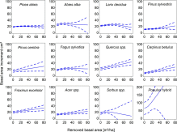

[figure not shown]

[figure not shown]

## [Forest Ecology and Management](https://www.sciencedirect.com/science/journal/03781127)

[Volume 480](https://www.sciencedirect.com/science/journal/03781127/480/supp/C), 15 January 2021, 118725

# Basal area increment models accounting for climate and mixture for Austrian tree species

[SonjaVospernik](https://www.sciencedirect.com/science/article/pii/S0378112720314948#!)

https://doi.org/10.1016/j.foreco.2020.118725[Get rights and content](https://s100.copyright.com/AppDispatchServlet?publisherName=ELS&contentID=S0378112720314948&orderBeanReset=true)

Under a Creative Commons [license](https://creativecommons.org/licenses/by-nc-nd/4.0/)

open access

## Highlights

**•**

Generalized additive basal area increment models were fit for 22 Austrian species.

**•**

Climatic effects were included using the long-term mean and deviations thereof.

**•**

This formulation separates climatic site effects from yearly weather conditions.

**•**

Positive and adverse mixture effects were included but no interactions could be fit.

**•**

The omission of National Inventory specific variables facilitates model application.

## Keywords

Basal area increment

Climate

Species mixture

Forest inventory

## 1. Introduction

Forest trees exhibit a large variation in basal area growth rate, which depends on tree specific factors, inter-tree relations and the environment. Well known and demonstrated by many studies is the increase of basal area increment with tree size or age (Stephenson et al., 2014). As trees grow, they are able to support more foliage, which in turn results in increased photosynthesis and carbon storage. For tree sizes usually found in forest inventories this increase is continuous (e.g. Monserud and Sterba, 1996). There is some discussion, however, if this increase in growth levels of for very old trees. Recent research, however, shows that at the individual tree level the continuous increase persists, at least in terms of carbon storage (Stephenson et al., 2014). Tree growth rates are species specific and the species specific response to the environment is also a major driver for large scale patterns of species presences and absence, because of competitive advantages and disadvantages of different tree species (Bueckling et al., 2017).

Competition is a key constraint to tree growth, which limits individual tree resources above and below-ground. The importance of competition for tree growth is well recognized and has been demonstrated in many studies (Biging and Dobbertin, 1992, Biging and Dobbertin, 1995, Weiskittel et al., 2011). Many different measures for competition or stand density have been proposed and indices are so numerous that they have been sorted into several different groups (Weiskittel et al., 2011). The suitability of different indices to predict tree growth has been compared in research (Biging and Dobbertin, 1992, Biging and Dobbertin, 1995). From these past studies it is evident that no single index has been shown to be a superior competition index in all situations, but some indices perform better with specific species in specific situations (Biging and Dobbertin, 1992, Biging and Dobbertin, 1995, Weiskittel et al., 2011). Thus comparative studies also show no clear advantage of more complex indices over simpler measures, indicating that most competition indices used in forest research are adequate (Biging and Dobbertin, 1992, Biging and Dobbertin, 1995, Weiskittel et al., 2011).

Climate change currently poses great challenges for forest research and with climate change a number of minor tree species such as *Acer* spp., *Betulus* spp., *Carpinus betulus* L., *Tilia* spp., *Sorbus* spp. and *Robinia pseudoacacia* L., which are recommended for very dry sites (Roloff and Grundmann, 2009), are receiving increasing attention. The response of trees to climate change has become an important research question and empirical research in this field has advanced considerably. Current efforts on individual tree growth modeling thus focus on including climatic effects in growth and mortality models. For example, Schmidt and Albert (2010) included mean temperature, precipitation, potential evapotranspiration and water balance during the growing season to predict site index for *Picea abies* and *Fagus sylvatica*. Nothdurft et al. (2012) modeled site index based on temperature sum and precipitation sum during the growing season. Climatic factors included in the height increment model of Kahn (1994) were mean temperature during the growing season, yearly temperature amplitude, aridity index according to DeMartonne (Martonne, 1926), precipitation during the growing season, length of growing season defined as the number of days with a mean temperature of $⩾$10 °C. Pokharel and Froese (2009) presented a climate-sensitive basal area increment model that included the number of days during the growing season, mean annual temperature, precipitation during the growing season and annual precipitation. The mortality model presented by Nothdurft (2013) included temperature and precipitation during the growing season and soil water holding capacity.

Simultaneously, research on mixtures has made considerable progress, but mixture effects have received less attention in forest growth models than climatic effects because they are assumed to emerge from the tree specific equations parameterized from data from both pure and mixed stands. To date, mixture effects have only been explicitly implemented in the basal area increment model presented by Vospernik and Sterba (2001). The authors showed that additional variables for mixture and the interaction between mixture and competition improved the model for the three main tree species. There are, however, good reasons to assume that mixture effects might not simply emerge from individual tree equations. Empirical research shows, that in mixtures, different tree species can positively or negatively affect each other (e.g. Kelty et al., 1992). Positive effects prevail, so that on average in mixtures, there are beneficial effects (Pretzsch and Schütze, 2009, Pretzsch et al., 2020), but results for individual plots can largely deviate from this mean (Huber et al., 2014, Pretzsch et al., 2020). The main reasons for positive mixture effects are tree specific differences in crown and root morphology (Canham et al., 1994, Kelty et al., 1992), water and nutrient use strategy (Pretzsch and Schütze, 2009), and different leaf and litter composition (Thelina et al., 2002, Aubert et al., 2006). These differences enable two or more species to exploit the resources of a site more efficiently than a single species. Thus, these mixture effects are thought to be particularly large if species specific traits strongly contrast. For example, the mixture of *Fagus sylvatica* and *Picea abies* is highly beneficial, and gains in mixture are reported to be 21% and 37% for *Picea abies* and *Fagus sylvatica*, respectively (Pretzsch and Schütze, 2009). Mixture gains for *Quercus* spp. and *Pinus sylvestris* are minor with 7% and 9%, respectively, because these two species have similar ecological traits (Pretzsch et al., 2020). Negative mixture effects are observed, if one tree species outcompetes the other species. For example, in mixtures of *Picea abies* and *Abies alba* Mill., positive mixture effects were only observed in 16% of the plots (Huber et al., 2014). Whether a mixture effect is positive or negative depends on age and/or size (Huber et al., 2014) and different site variables such as temperature (Huber et al., 2014), precipitation (Huber et al., 2014), aridity index (Pretzsch et al., 2020), site index (Pretzsch et al., 2020), site quality (Huber et al., 2014), slope (Huber et al., 2014), and aspect (Huber et al., 2014).

Studying the effect of the above factors of tree growth is essential for forest management and basal area increment models as part of individual tree growth simulators can also provide flexible predictions of forest growth (Weiskittel et al., 2011, p. 69). Individual tree growth simulators have been successfully applied to predict growth and yield for individual research plots (Pretzsch, 2002, Schmidt and Hansen, 2007, Vospernik et al., 2015) or to predict growth and yield for large areas (Pretzsch, 2002). Numerous researchers have simulated forest management scenarios (Vospernik and Reimoser, 2008, Engel et al., 2020) and the results have been linked to other models, e.g. wood quality (Maguire et al., 1991), habitat quality (Debeljak et al., 2001, Vospernik and Reimoser, 2008), or rockfall protection (Brauner et al., 2005).

For Austria, the individual tree growth model Prognaus has been developed (Monserud and Sterba, 1996, Monserud and Sterba, 1999, Hasenauer and Monserud, 1996, Nachtmann, 2006) from the data of the Austrian National Forest Inventory. The initial basal area increment model was estimated by Monserud and Sterba (1996) and re-parameterized by Hasenauer (2000) using simultaneous equations. Kindermann (2010) presented a climate-sensitive basal area increment model for 6 major tree species, where climatic effects were modeled by the yearly temperature sum of days above 3 °C and yearly precipitation. This last variant of the basal area increment model does not yet include mixture effects. Also, with climatic warming, basal area increment models for a larger number of tree species might be required. For example, *Fraxinus excelsior* L. and *Acer pseudoplatanus* L. are frequently discussed in the context of climatic warming. These two species are sufficiently represented by the Austrian National Forest Inventory, but models for them both are lacking. Furthermore, a model parameterized for Austria, could be easily be transferred to other regions in Europe and elsewhere as an evaluation study by (Engel et al., 2020).

The objective of this paper was to parameterize a basal area increment model for Austrian tree species that includes mixture and climatic effects. In addition, disturbance effects, which are already part of the basal area increment model of other individual tree growth simulators (Hasenauer, 1994, Nagel, 2009, Pretzsch and Biber, 2002), were included. Evaluation studies showed that the individual tree growth models of Prognaus reacts conservatively to thinning, underestimating the compensatory effect of the remaining trees (Vospernik et al., 2015). An additional variable for tree removal might therefore improve this behavior. All tree species with more than 200 trees observed by the Austrian National Forest Inventory, were modeled. Site factors were selected in such a way that they were as generic as possible and so that the model could be replicated in other regions.

## 2. Material and methods

### 2.1. Data

#### 2.1.1. Forest Inventory data

For this research the plots starting from the first permanent assessment till today were used. These are the plots from the third (1981–1985), fourth (1986–1990), fifth (1992–1996), sixth (2000–2002), and seventh (2007–2009) Austrian National Forest Inventory (ANFI)(Forstliche Bundesversuchsanstalt, 1994), while the eighth is still in progress. The ANFI is a systematic inventory over all of Austria. ANFI clusters are located at the nodes of a 3.89 × 3.89 km<sup>2</sup> grid. Each cluster contains four sample plots, which are located at the corners of a 200 × 200-m square. On each sample plot, trees with a dbh of 5 to 10.4 cm were sampled in fixed radius plots with a radius of 2.6 m, which is the critical distance for a 10.4 cm tree in angle counts (Bitterlich, 1948) with a basal area factor (BAF) of 4 m<sup>2</sup>/ha; trees with a dbh of >10.4 cm were selected by angle count sampling with BAF = 4 m<sup>2</sup>/ha. Plots, which were situated entirely in the forest and were not bisected by forest roads, were selected and the following variables were calculated: quadratic mean diameter, dominant height, basal area, crown competition factor (Krajicek et al., 1961), stand density index (Reineke, 1993), basal area of larger trees (BAL) (Wykoff, 1990), relative density, i.e. basal area of each species divided by its maximum basal area and summed up for the plot, and relative diameter, i.e. dbh related to quadratic mean diameter. Reference maximum basal area was derived from functions published by Vospernik and Sterba (2015). 22 tree species were included in the analysis and the descriptive statistics for these species are shown in Table 1.

Table 1. Mean, minimum and maximum values for basal area increment, dbh, basal area of larger trees (Wykoff, 1990) basal area, temperature and precipitation during the growing season for each tree species from the Austrian National Forest Inventory data and the Histalp-data set.

| Species | Species | No. obs | BAI (cm<sup>2</sup>year<sup>−1</sup>) mean | BAI (cm<sup>2</sup>year<sup>−1</sup>) min | BAI (cm<sup>2</sup>year<sup>−1</sup>) max | dbh (cm) mean | dbh (cm) min | dbh (cm) max | BAL (m<sup>2</sup>ha<sup>−1</sup>) mean | BAL (m<sup>2</sup>ha<sup>−1</sup>) min | BAL (m<sup>2</sup>ha<sup>−1</sup>) max | BA (m<sup>2</sup>ha<sup>−1</sup>) mean | BA (m<sup>2</sup>ha<sup>−1</sup>) min | BA (m<sup>2</sup>ha<sup>−1</sup>) max | Veg T °C mean | Veg T °C min | Veg T °C max | Veg P (mm) mean | Veg P (mm) min | Veg P (mm) max |
| --- | --- | --- | --- | --- | --- | --- | --- | --- | --- | --- | --- | --- | --- | --- | --- | --- | --- | --- | --- | --- |
| Norway spruce | *Picea abies* (L.) Karst. | 145834 | 18 | −184 | 307 | 31 | 5 | 134 | 19 | 0 | 116 | 41 | 1 | 124 | 10.3 | −0.5 | 15.8 | 707 | 286 | 1349 |
| Silver fir | *Abies alba* Mill. | 9627 | 24 | −83 | 209 | 37 | 5 | 126 | 19 | 0 | 120 | 43 | 1 | 124 | 11.0 | 2.9 | 15.5 | 789 | 341 | 1349 |
| European larch | *Larix decidua* Mill. | 16559 | 17 | −125 | 196 | 37 | 5 | 133 | 14 | 0 | 100 | 40 | 1 | 116 | 9.6 | −0.4 | 15.3 | 695 | 279 | 1227 |
| Scots pine | *Pinus sylvestris* L. | 19363 | 10 | −55 | 94 | 30 | 5 | 72 | 15 | 0 | 88 | 40 | 1 | 116 | 12.5 | −0.4 | 15.8 | 560 | 286 | 1149 |
| Austrian pine | *Pinus nigra* Arnold | 2713 | 10 | −55 | 111 | 32 | 5 | 95 | 19 | 0 | 80 | 45 | 4 | 89 | 13.0 | 9.0 | 15.5 | 484 | 290 | 875 |
| Stone pine | *Pinus cembra* L. | 1397 | 14 | −61 | 100 | 40 | 5 | 117 | 15 | 0 | 72 | 35 | 2 | 100 | 7.1 | 0.0 | 13.3 | 690 | 517 | 1147 |
| European beech | *Fagus sylvatica* L. | 24213 | 17 | −78 | 216 | 31 | 5 | 126 | 20 | 0 | 104 | 39 | 1 | 108 | 11.8 | 2.9 | 15.8 | 709 | 311 | 1343 |
| Oak | *Quercus* spp. | 5565 | 21 | −38 | 174 | 33 | 5 | 136 | 12 | 0 | 68 | 32 | 1 | 83 | 13.9 | 8.4 | 16.0 | 463 | 279 | 1050 |
| Hornbeam | *Carpinus betulus* L. | 2386 | 7 | −48 | 84 | 18 | 5 | 65 | 20 | 0 | 80 | 32 | 1 | 86 | 13.8 | 7.2 | 15.8 | 481 | 282 | 1040 |
| Ash | *Fraxinus excelsior* L. | 3532 | 19 | −45 | 175 | 27 | 5 | 102 | 17 | 0 | 76 | 34 | 1 | 92 | 12.6 | 4.3 | 16.1 | 646 | 279 | 1270 |
| Sycamore | *Acer* spp. | 3208 | 12 | −56 | 132 | 27 | 5 | 108 | 20 | 0 | 84 | 36 | 1 | 90 | 11.4 | 2.9 | 16.1 | 729 | 280 | 1349 |
| Elm | *Ulmus* spp. | 339 | 15 | −49 | 90 | 27 | 5 | 81 | 17 | 0 | 76 | 31 | 1 | 92 | 11.9 | 3.2 | 16.1 | 726 | 282 | 1270 |
| European chestnut | *Castanea sativa* Mill. | 291 | 17 | −12 | 95 | 23 | 5 | 67 | 15 | 0 | 56 | 31 | 1 | 96 | 14.0 | 11.4 | 15.7 | 567 | 346 | 750 |
| Black locust | *Robinia pseudoacacia* L. | 498 | 9 | −11 | 66 | 16 | 5 | 42 | 10 | 0 | 50 | 22 | 1 | 83 | 14.5 | 11.4 | 16.1 | 385 | 275 | 632 |
| Sorbus | *Sorbus* spp. | 869 | 7 | −25 | 89 | 19 | 5 | 51 | 23 | 0 | 100 | 36 | 1 | 102 | 12.2 | 1.4 | 15.8 | 636 | 279 | 1213 |
| Birch | *Betulus* spp. | 2039 | 7 | −30 | 76 | 19 | 5 | 50 | 17 | 0 | 80 | 34 | 1 | 92 | 11.8 | 1.8 | 15.7 | 577 | 279 | 1100 |
| Black alder | *Alnus glutinosa* Gaertn. | 1210 | 11 | −22 | 88 | 23 | 5 | 58 | 17 | 0 | 88 | 36 | 1 | 102 | 13.5 | 7.4 | 15.8 | 539 | 308 | 1040 |
| Grey alder | *Alnus incana* Moench | 1220 | 5 | −16 | 52 | 15 | 5 | 42 | 17 | 0 | 66 | 31 | 1 | 69 | 9.9 | 2.1 | 15.6 | 712 | 340 | 1270 |
| Lime | *Tilia* spp. | 589 | 13 | −46 | 146 | 24 | 5 | 87 | 18 | 0 | 68 | 36 | 1 | 86 | 13.4 | 7.3 | 15.8 | 471 | 279 | 827 |
| White poplar | *Populus alba* L. | 537 | 26 | −23 | 141 | 30 | 5 | 82 | 13 | 0 | 52 | 32 | 3 | 70 | 13.5 | 1.8 | 15.7 | 491 | 279 | 1095 |
| Hybrid poplar | *Populus hybridus* | 419 | 63 | −6 | 251 | 42 | 6 | 98 | 10 | 0 | 44 | 28 | 2 | 60 | 14.4 | 8.2 | 16.1 | 418 | 294 | 749 |
| Willow | *Salix* spp. | 401 | 24 | −23 | 301 | 23 | 5 | 114 | 11 | 0 | 52 | 26 | 2 | 66 | 12.2 | 6.6 | 15.6 | 604 | 274 | 1141 |

#### 2.1.2. Climatic data

The climatic data used for this research is the Histalp-data set (http://www.zamg.ac.at/histalp/dataset/grid/five_min.php). The histalp data set is a 5 min × min grid data set that contains monthly mean temperature and monthly precipitation dating back to the year 1780 for temperature and 1801 for precipitation. The temperature data set was created by merging climate mean grids (1961–1990) with long-term station data (Hiebl et al., 2009). The grids of total precipitation were calculated from the monthly precipitation analysis of Efthymiadis et al. (2006) and the same grid as for the temperature data set was used. The effective coverage of the data depends on the availability of observations in the station network which progressively declines towards the early 19th century (from 192 to 5 stations) (Efthymiadis et al., 2006), but coverage is very good for the period 1981–2009, which was used in this analysis. The gridded temperature and precipitation data were used to calculate potential evapotranspiration according to Thornthwaite’s equation (Thornthwaite, 1948) and to calculate the following drought indices: de-Martonne index (Martonne, 1926), standard precipitation index (SPI) (McKee et al., 1993) and standardized precipitation-evapotranspiration index (SPIE) (Vicente-Serrano et al., 2010).

The de-Martonne index (dMI) is a simple index, which is calculated as $dMI=PT+10$, where *P* denotes the annual precipitation sum and *T* denotes the mean temperature. The SPI is the drought index that is recommended by the world meteorological organization. It is widely used, because it is comparable across regions, and permits researchers to determine the rarity of a current drought. For SPI a gamma-distribution or a Pearson-Type III distribution is fit to the climate data of a reference period. SPI is a type of *z*-score, i.e. the index measures the distance of the observed precipitation in terms standardized departure from the fitted distribution. Values of more than +2 or less than −2 are classified as extreme (McKee et al., 1993). Similarly, SPIE expresses the deviations of the current climatic balance (precipitation–minus evapotranspiration potential) in terms of *z*-scores.

### 2.2. Statistical methods

Basal area increment was modeled with a generalized additive model (GAM). In generalized additive models, the linear predictor depends linearly on unknown smooth functions of some predictor variables, and interest focuses on inference about these smooth functions. GAMs were originally developed by Hastie and Tibshirani (1990) and blend properties of additive models with generalized linear models. A univariate response variable, *Y*, is related to a predictor variables and an exponential family distribution is specified for *Y* along with a link-function, *g*. For basal area increments, first a normal distribution with log-link function was specified. Functions within the GAM-framework may be specified in a parametric form or may be specified non-parametrically, simply as smooth functions. GAMs were estimated using the mgcv-package (Wood, 2011, Wood, 2017) in R (R Core Team, 2018), which implements numerous different smooth functions. After some testing, the default smooth functions, which are thin plate regression splines, were used for continuous variables, and parametric functions were used for categorical variables. Thin plate regression splines estimate the smoothing function by minimizing the least squares criterion subject to a roughness penalty based on second derivatives, i.e. if the second derivatives are zero, the function is linear and thus departures from linearity (smoothness) are penalized. Thin plate regression splines have good extrapolation properties. To test for interactions, both isotropic smooths of multiple predictors and tensor product smooths were included. Isotropic smooths are suitable for variables which all have the same units (e.g. coordinates), whereas tensor product smooths allow different flexibility in different directions and are scale invariant. The number of knots, *k*, specified for the smooth function determines the degree of flexibility of the smooth function. It was set to 20 for most variables, which is higher than *k* = 10 used as default in the mgcv-package. In some cases, however, the number of knots had to be reduced in order prevent the GAM from tracing individual data points. In terms of forest growth the model specified as(1)$g(E(BAI))=β0+f1(Size)+f2(CompD)+f3(HDis)+f4(Clim)+β5(Soil)+f6(Mixt)$$fi$ are smooth functions of *Size*, *CompD*, *HDis*, *Clim*, *Mixt*, and $β5$ parametric coefficients of *Soil*. *Size*, *CompD*, *HDis*, *Climate*, *Soil*, *Mixt* stand for numerous possible variables that could be included to describe the respective growth component and mean: *Tree size*, *competition and density*, *harvesting and disturbances*, *climate factors*, *soil factors*, *tree species mixture*. Because of the multitude of possible variables available for each component in the Austrian National Forest Inventory data, modeling was carried out variable group by variable group. Within each group, predictor variables for the main effects were selected based on the lowest Akaike information criterion AIC (Akaike, 1973) and possible interactions were tested. After the variables for each group were selected, interactions between variables of different groups were tested. A quasi-distribution was finally used to account for overdispersion. Since quasi families do not have full likelihoods, gam uses the notation of extended quasi-likelihood from McCullagh and Nelder (1989).

In the GAM framework, also random effects can be easily coded. Although the benefits for incorporating such effects are undeniable, there is a major drawback. Unlike the linear counterpart, the conditional mean depends on the random effects in a non-linear fashion. Thus, while in the linear mixed-model the random effects can be set to 0 for the prediction of data sets where the random effects are unknown, this does not hold for a non-linear model and may introduce a bias in the prediction of data sets with unknown random effects (Greene, 2001, Harring and Liu, 2016). Since the model was also intended for integration in an individual tree growth model with the aim of prediction for different data, the models were parameterized without random effects. Moreover, the inclusion of random effects for major tree species is computationally very expensive. The model without random effects the parameter estimates are still unbiased, but variances may be biased and inconsistent (Lang and Laird, 1989).

## 3. Results

### 3.1. Size, density, competition, and change in competition

Table 2. Table of approximated significance of the smoothed terms of the GAM for size, density, competition, disturbances and harvesting, climate and mixture. The table shows the effective degrees of freedom. Pa - *Picea abies* Karst., Aa - *Abies alba* Mill., Ld - *Larix decidua* Mill., Ps - *Pinus sylvestris* L., Pn - *Pinus nigra* Arnold, Pc - *Pinus cembra* L., Fs - *Fagus sylvatica* L., Qs - *Quercus* spp., Cp - *Carpinus betulus* L., Fe - *Fraxinus excelsior* L., As - *Acer* spp. Us - *Ulmus* spp., Cs - *Castanea sativa*, Rp - *Robinia pseudoacacia* L., Ss - *Sorbus* spp., Bs - *Betulus* spp., Ag - *Alnus glutinosa* Gaertn., Ai - *Alnus incana* Moench, Ts - *Tilia* spp., Popa - *Populus alba* L., Poph - *Populus hybridus*, Sa - *Salix* spp., dbh - diameter at breast height, cm, ba - basal area, m<sup>2</sup>/ha, ba rem. - basal area removed, m<sup>2</sup>/ha, LTM Prec. - Long term mean precipitation (1960–2009) during the growing season, mm, LTM T. - Long term mean temperature (1960–2009) during the growing season, °C, pos. Prec. - Yearly positive deviation of precipitation from the long term mean during the inventory period, mm, pos. T. - Yearly positive deviation of temperature from the long term mean during the inventory period, °C, neg. Prec. - Yearly negative deviation of precipitation from the long term mean during the inventory period, mm, neg. T. - Yearly negative deviation of temperature from the long term mean during the inventory period, °C, p. - Proportion of the respective tree species.

| Variable | Pa | Aa | Ld | Ps | Pn | Pc | Fs | Qs | Cb | Fe | As |
| --- | --- | --- | --- | --- | --- | --- | --- | --- | --- | --- | --- |
| s(dbh) | 15.5484 | 10.3458 | 12.2426 | 6.9213 | 4.3351 | 1.2829 | 13.4223 | 13.6057 | 1.0582 | 6.0905 | 4.5940 |
| s(ba) | 5.5884 | 3.1475 | 3.3669 | 6.6755 | 3.1774 | 4.1673 | 7.1715 | 4.2302 | 2.0130 | 1.0046 | 2.6603 |
| s(BAL) | 10.1011 | 4.8783 | 4.0501 | 5.3720 | 1.1882 | 1.0001 | 6.9291 | 2.6656 | 4.4897 | 3.6050 | 3.6489 |
| s(ba rem.) | 3.6178 | 3.1285 | 3.3115 | 2.9925 |  | 1.0012 | 3.1542 | 1.0291 | 1.1463 | 1.0012 | 1.0108 |
| s(LTM Prec.) | 17.7349 | 5.7053 | 2.5239 | 11.8011 | 3.7300 | 2.5938 | 15.2045 | 10.4278 | 4.3040 | 13.0424 | 6.2295 |
| s(LTM T.) | 16.0487 | 5.3058 | 8.2458 | 5.7820 | 3.8738 |  | 12.8158 | 3.1657 | 2.9832 | 1.0543 | 1.0138 |
| s(pos. Prec.) | 4.7959 | 1.9516 | 1.0267 | 7.6165 | 3.2228 | 1.0008 | 4.5888 | 4.5559 |  |  |  |
| s(pos. T.) | 17.0538 | 1.0144 | 1.9380 | 1.0518 | 4.1086 | 6.0851 | 3.9062 | 1.5219 |  |  |  |
| s(neg. Prec.) | 11.4995 | 1.0064 | 1.0221 | 1.0228 | 2.2037 | 1.7033 | 6.2853 | 3.1009 |  |  |  |
| s(neg. T.) | 17.0145 | 3.3559 | 7.7920 | 13.8599 | 3.6313 | 1.0094 | 13.6022 | 3.8295 |  |  |  |
| s(Pa p.) |  | 5.8988 | 1.0218 |  |  |  | 3.0409 | 1.0112 |  |  |  |
| s(Aa p.) | 6.9054 |  |  |  |  |  | 1.0095 |  |  |  |  |
| s(Ld p.) | 6.0223 | 1.1789 |  | 1.0247 |  |  | 1.6532 |  |  |  |  |
| s(Ps p.) | 4.7125 |  |  |  |  |  | 2.8912 |  |  |  |  |
| s(Pc p.) | 2.0738 |  | 1.2595 |  |  |  |  |  |  |  |  |
| s(Fs p.) | 13.8584 | 2.5341 | 1.0134 | 1.6215 |  |  |  |  |  | 2.2511 | 1.0036 |
| s(Qs p.) | 3.9057 |  |  | 6.7063 |  |  | 1.0154 |  |  |  | 3.9434 |
| s(Cp p.) | 3.3395 |  |  |  |  |  | 3.7103 |  |  |  |  |
| s(Fe p.) | 3.7269 |  |  |  |  |  | 2.3461 | 2.0267 |  |  |  |
| s(As p.) | 3.1885 |  |  |  |  |  | 4.7028 |  |  | 1.0200 |  |
| s(Bs p.) | 3.2122 |  | 3.6563 | 1.0162 |  |  | 2.9715 |  |  |  |  |
| s(Ss p.) | 1.1940 |  |  |  |  |  |  |  |  | 2.7417 |  |
| s(Ai p.) | 3.6059 |  |  |  |  |  |  |  |  |  |  |
| s(Sa p.) | 2.6679 |  |  |  |  |  |  |  |  |  |  |
| R<sup>2</sup> | 0.387 | 0.404 | 0.256 | 0.198 | 0.236 | 0.212 | 0.462 | 0.459 | 0.339 | 0.511 | 0.302 |

Table 3. Table of approximated significance of the smoothed terms of the GAM for size, density, competition, disturbances and harvesting, climate and mixture. The table shows the effective degrees of freedom. Pa - *Picea abies* Karst., Aa - *Abies alba* Mill., Ld - *Larix decidua* Mill., Ps - *Pinus sylvestris* L., Pn - *Pinus nigra* Arnold, Pc - *Pinus cembra* L., Fs - *Fagus sylvatica* L., Qs - *Quercus* spp., Cp - *Carpinus betulus* L., Fe - *Fraxinus excelsior* L., As - *Acer* spp. Us - *Ulmus* spp., Cs - *Castanea sativa*, Rp - *Robinia pseudoacacia* L., Ss - *Sorbus* spp., Bs - *Betulus* spp., Ag - *Alnus glutinosa* Gaertn., Ai - *Alnus incana* Moench, Ts - *Tilia* spp., Popa - *Populus alba* L., Poph - *Populus hybridus*, Sa - *Salix* spp., ba - basal area, m<sup>2</sup>/ha, ba rem. - basal area removed, m<sup>2</sup>/ha, LTM Prec. - Long term mean precipitation (1960–2009) during the growing season, mm, LTM T. - Long term mean temperature (1960–2009) during the growing season, °C, pos. Prec. - Yearly positive deviation of precipitation from the long term mean during the inventory period, mm, pos. T. - Yearly positive deviation of temperature from the long term mean during the inventory period, °C, neg. Prec. - Yearly negative deviation of precipitation from the long term mean during the inventory period, mm, neg. T. - Yearly negative deviation of temperature from the long term mean during the inventory period, °C, p. - Proportion of the respective tree species.

| Variable | Us | Cs | Rp | Ss | Bs | Ag | Ai | Ts | Popa | Poph | Sa |
| --- | --- | --- | --- | --- | --- | --- | --- | --- | --- | --- | --- |
| s(dbh) | 6.0041 | 5.6003 | 3.1369 | 1.6092 | 4.1709 | 1.9069 | 2.3853 | 1.0021 | 1.5620 | 2.6800 | 6.9294 |
| s(ba) | 2.8276 | 1.0009 | 4.3207 | 3.2184 | 3.0786 | 1.0014 |  |  |  | 2.7609 |  |
| s(BAL) | 2.7826 | 1.0002 |  | 4.8808 | 4.8948 | 2.5786 | 2.8107 |  |  | 1.0080 | 1.7834 |
| s(ba rem.) |  |  |  | 2.1009 |  |  |  |  |  | 1.8321 |  |
| s(LTM Prec.) |  |  | 4.1298 |  |  |  | 2.0419 | 5.6710 |  | 4.8498 |  |
| s(LTM T.) | 3.2167 | 1.0008 | 3.6890 | 5.6542 | 4.2307 | 6.7420 |  | 1.0016 |  | 5.7323 |  |
| s(pos. Prec.) |  | 2.0606 | 1.0023 |  | 1.5343 | 1.0020 | 2.7517 |  | 3.0931 |  | 1.0009 |
| s(pos. T.) |  | 1.6643 | 1.0006 |  | 1.0129 | 1.0004 | 3.468 |  | 2.6497 |  | 1.0003 |
| s(neg. Prec.) |  | 1.3866 | 4.7379 |  | 1.0132 | 5.6029 | 1.0120 |  | 4.3793 |  | 1.0013 |
| s(neg. T.) |  | 2.6110 | 1.0004 |  | 1.0030 | 1.0018 | 1.0007 |  | 1.8786 |  | 2.1610 |
| s(Pa p.) |  |  |  |  |  |  | 1.0066 |  |  |  |  |
| R<sup>2</sup> | 0.316 | 0.567 | 0.454 | 0.423 | 0.253 | 0.387 | 0.298 | 0.344 | 0.399 | 0.421 | 0.616 |

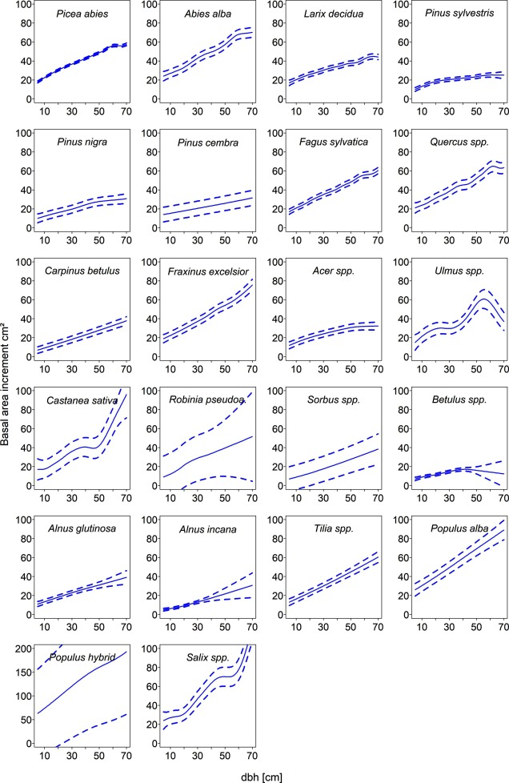

1. [Download : Download high-res image (1MB)](https://ars.els-cdn.com/content/image/1-s2.0-S0378112720314948-gr1_lrg.jpg)
2. [Download : Download full-size image](https://ars.els-cdn.com/content/image/1-s2.0-S0378112720314948-gr1.jpg)

Fig. 1. Annual basal area increment in cm<sup>2</sup> of different tree species over dbh in cm. Robinia pseudoa. - *Robinia pseudoacacia* L.

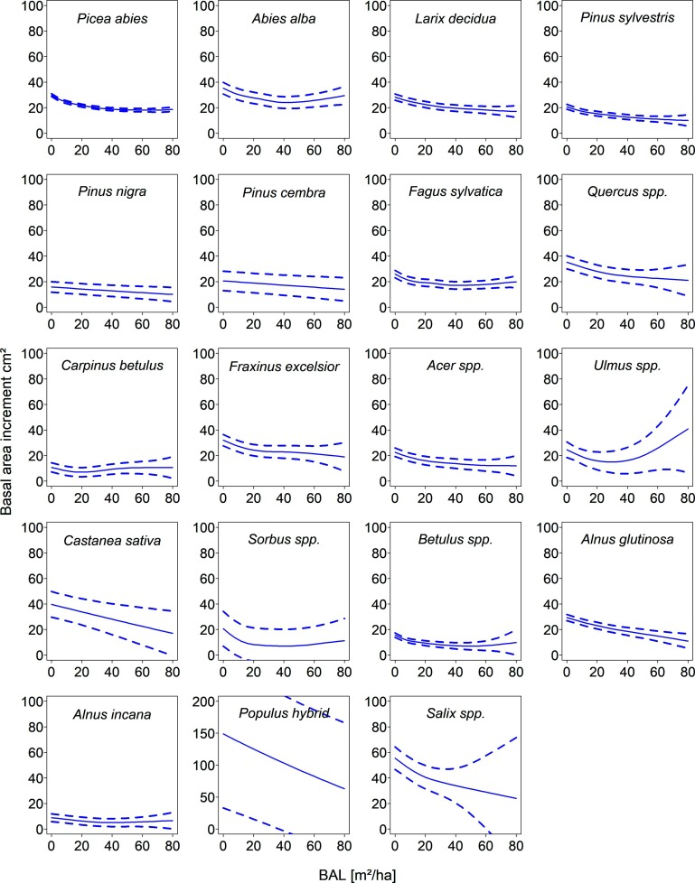

1. [Download : Download high-res image (1MB)](https://ars.els-cdn.com/content/image/1-s2.0-S0378112720314948-gr2_lrg.jpg)
2. [Download : Download full-size image](https://ars.els-cdn.com/content/image/1-s2.0-S0378112720314948-gr2.jpg)

Fig. 2. Annual basal area increment in cm<sup>2</sup> of different tree species over basal area of larger trees, BAL (Wykoff, 1990) in m<sup>2</sup>/ha. *Robinia pseudoa.* - *Robinia pseudoacacia* L.

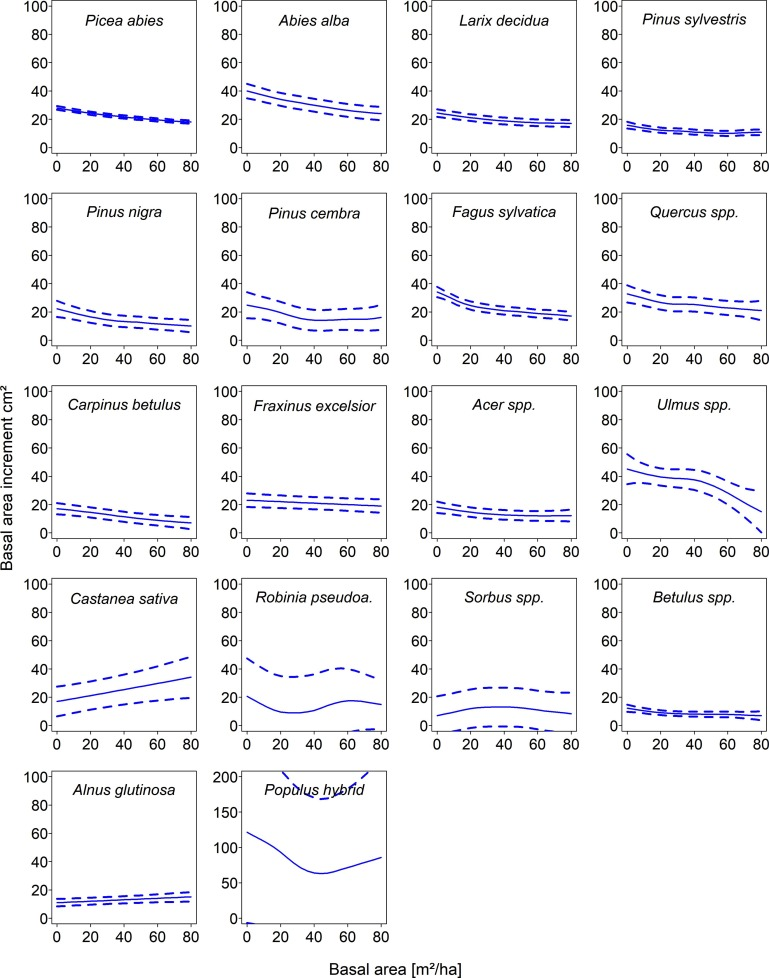

1. [Download : Download high-res image (1MB)](https://ars.els-cdn.com/content/image/1-s2.0-S0378112720314948-gr3_lrg.jpg)
2. [Download : Download full-size image](https://ars.els-cdn.com/content/image/1-s2.0-S0378112720314948-gr3.jpg)

Fig. 3. Annual basal area increment in cm<sup>2</sup> of different tree species over basal area in m<sup>2</sup>/ha. *Robinia pseudoa.* - *Robinia pseudoacacia* L.

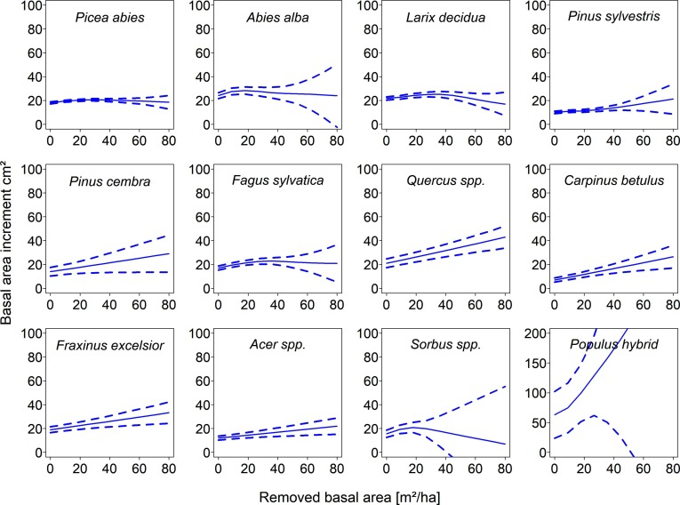

1. [Download : Download high-res image (706KB)](https://ars.els-cdn.com/content/image/1-s2.0-S0378112720314948-gr4_lrg.jpg)
2. [Download : Download full-size image](https://ars.els-cdn.com/content/image/1-s2.0-S0378112720314948-gr4.jpg)

Fig. 4. Annual basal area increment in cm<sup>2</sup> of different tree species over removed basal area in m<sup>2</sup>/ha, i.e. basal area of trees that where removed due to disturbances or regular harvesting. *Robinia pseudoa.* - *Robinia pseudoacacia* L.

### 3.2. Climate

The most difficult component to include in the basal area increment models were climate effects. Due to the currently increased interest in climate change, numerous climate indices have been developed. The following climate indices were considered: deMartonne index (Martonne, 1926), the standardized precipitation index (SPI) (McKee et al., 1993) and standardized precipitation-evapotranspiration index (SPIE) (Vicente-Serrano et al., 2010). The latter two indices can be created for differing periods and periods of 1, 3, 6 and 12-month were tested. If two climate variables were used, results consistently showed the lowest AIC for models including temperature and precipitation. If a third climate variable was added, the model with potential evapotranspiration had a lower AIC than models including the dryness indices. If the dryness indices SPI and SPIE were included in the model, these two variables were almost interchangeable, with the best temporal resolution being highly variable. The best reference period for these indices was often 6 months, but also 3 months and 1 month, but never 12 months. In general, models with three climatic variables were only marginally better than models including only temperature and precipitation and so the simpler model was adopted.

Climatic variables are available at different temporal resolutions, which are monthly, quarterly, semi-annual or yearly climate values. In principle, the highest temporal resolution of climate effects resulted in the lowest AIC. However, for only a few species sufficient data were available to model climatic effects with a monthly resolution and the models partly showed biologically implausible behavior. Thus, models including climate during the growing season, defined as the period from the 1 st of April to the 30 th of September, were fit for all species.

Explanatory capacity of temperature and precipitation during the growing seasons was, however, still weak and suggested a reformulation of climatic effects into long-term mean temperature and precipitation (1960–2009) and positive and negative yearly deviations from the long-term mean temperature during the inventory period.

Reactions to the long-term mean temperature and precipitation reflect species specific differences in warmth and moisture requirements (Fig. 5, Fig. 6). *Picea abies*, an ubiquitous trees species in Austria, showed little response over the wide range of observed temperatures and precipitation values, with a decrease in BAI only on very dry and warm sites and sites with overabundant precipitation, typical of high elevation forests. Similarly, the growth of *Fagus sylvatica* was unaffected over a wide range of temperature conditions, but this more thermophilic species showed a sharp decrease in growth when temperatures fell below 5 °C. Similarly, tree species of the foothill zone (e.g. *Pinus nigra*, *Quercus* spp., *Alnus glutinosa*), showed a clear decrease in BAI for temperatures below 10 °C. The tremendous increase in confidence intervals indicates the absence of these species on colder sites. Tree species of xeric sites also have extremely large confidence intervals for higher precipitation values where these species are not found. At the other end of the species range are species adapted to cold temperatures. In Austria, these are typically *Larix decidua* and *Pinus cembra*. Both species behave rather indifferently over the whole temperature range with long-term mean temperature not being significant for *Pinus cembra*. Both species were, however, sensitive to an increase in precipitation, which is typical of sites with long snow cover. This decrease in precipitation was more pronounced for *Pinus cembra*. (Fig. 7, Fig. 8, Fig. 9, Fig. 10).

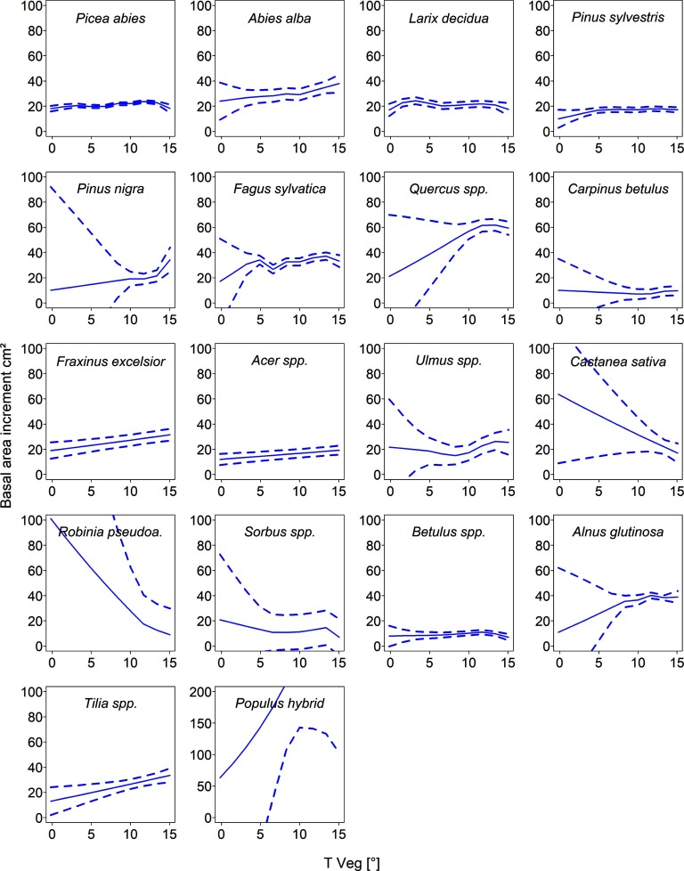

1. [Download : Download high-res image (1MB)](https://ars.els-cdn.com/content/image/1-s2.0-S0378112720314948-gr5_lrg.jpg)
2. [Download : Download full-size image](https://ars.els-cdn.com/content/image/1-s2.0-S0378112720314948-gr5.jpg)

Fig. 5. Annual basal area increment in cm<sup>2</sup> of different tree species over long-term mean temperature (1960–2009) during the growing season in °C. *Robinia pseudoa.* - *Robinia pseudoacacia* L.

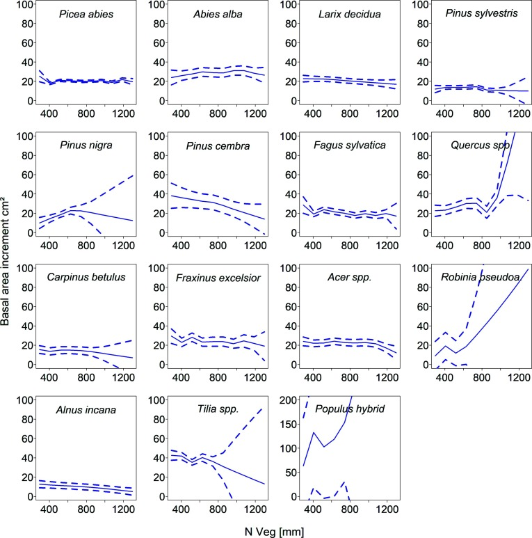

1. [Download : Download high-res image (929KB)](https://ars.els-cdn.com/content/image/1-s2.0-S0378112720314948-gr6_lrg.jpg)
2. [Download : Download full-size image](https://ars.els-cdn.com/content/image/1-s2.0-S0378112720314948-gr6.jpg)

Fig. 6. Annual basal area increment in cm<sup>2</sup> of different tree species over long term mean precipitation (1960–2009) during the growing season in mm. *Robinia pseudoa.* - *Robinia pseudoacacia* L.

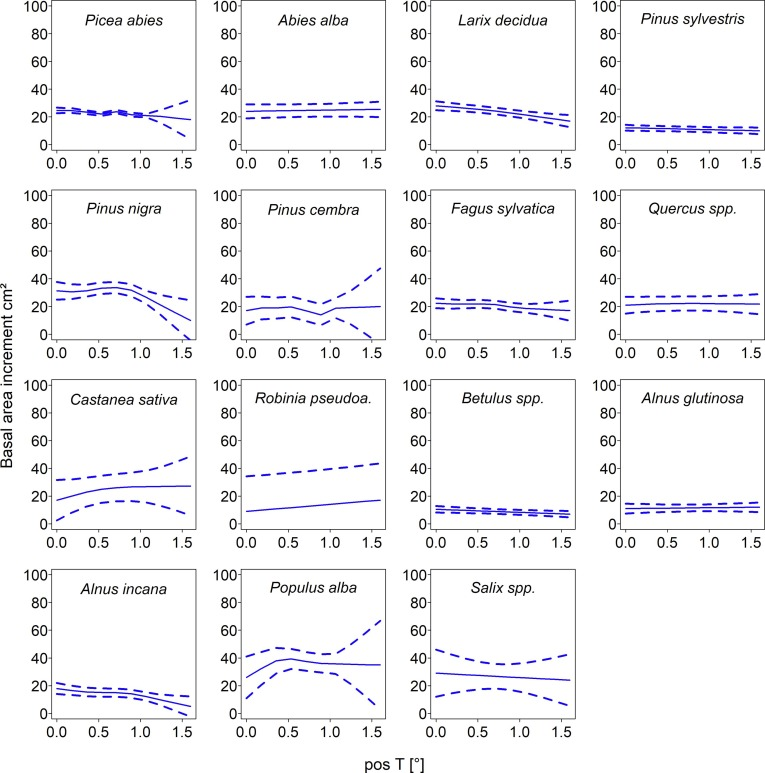

1. [Download : Download high-res image (810KB)](https://ars.els-cdn.com/content/image/1-s2.0-S0378112720314948-gr7_lrg.jpg)
2. [Download : Download full-size image](https://ars.els-cdn.com/content/image/1-s2.0-S0378112720314948-gr7.jpg)

Fig. 7. Annual basal area increment in cm<sup>2</sup> of different tree species over yearly positive temperature deviations during the inventory period from the long-term mean temperature (1960–2009) of the respective site in °C. *Robinia pseudoa.* - *Robinia pseudoacacia* L.

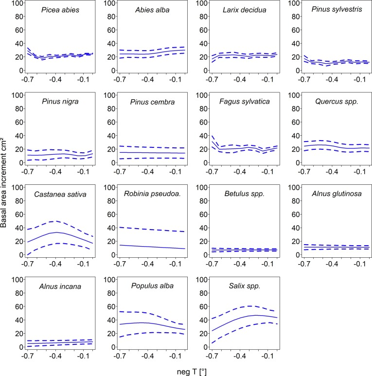

1. [Download : Download high-res image (795KB)](https://ars.els-cdn.com/content/image/1-s2.0-S0378112720314948-gr8_lrg.jpg)
2. [Download : Download full-size image](https://ars.els-cdn.com/content/image/1-s2.0-S0378112720314948-gr8.jpg)

Fig. 8. Annual basal area increment in cm<sup>2</sup> of different tree species over negative yearly temperature deviations during the inventory period from the long-term mean temperature (1960–2009) of the respective site in °C. *Robinia pseudoa.* - *Robinia pseudoacacia* L.

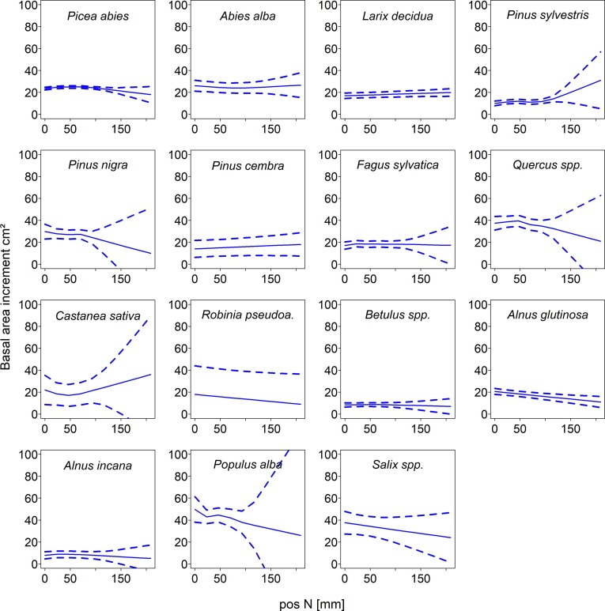

1. [Download : Download high-res image (808KB)](https://ars.els-cdn.com/content/image/1-s2.0-S0378112720314948-gr9_lrg.jpg)
2. [Download : Download full-size image](https://ars.els-cdn.com/content/image/1-s2.0-S0378112720314948-gr9.jpg)

Fig. 9. Annual basal area increment in cm<sup>2</sup> of different tree species over positive yearly precipitation deviations during the inventory period from the long-term mean precipitation (1960–2009) of the respective site in mm. *Robinia pseudoa.* - *Robinia pseudoacacia* L.

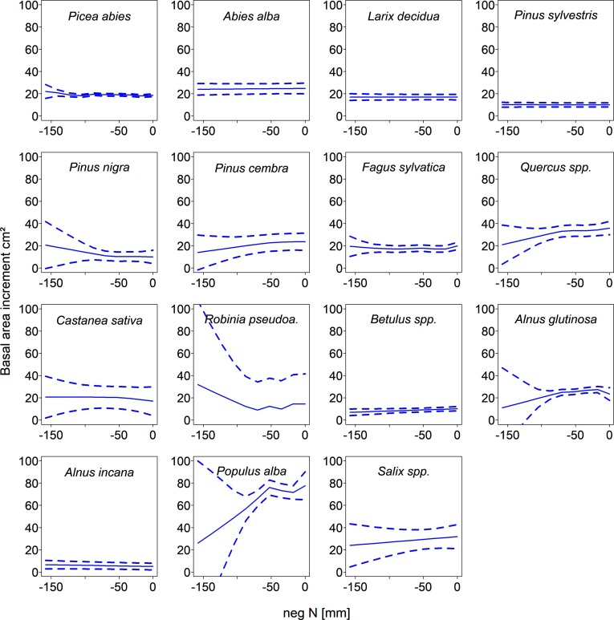

1. [Download : Download high-res image (820KB)](https://ars.els-cdn.com/content/image/1-s2.0-S0378112720314948-gr10_lrg.jpg)
2. [Download : Download full-size image](https://ars.els-cdn.com/content/image/1-s2.0-S0378112720314948-gr10.jpg)

Fig. 10. Annual basal area increment in cm<sup>2</sup> of different tree species over negative yearly precipitation deviations during the inventory period from the long-term mean precipitation (1960–2009) of the respective site in mm. *Robinia pseudoa.* - *Robinia pseudoacacia* L.

### 3.3. Soil type and soil moisture

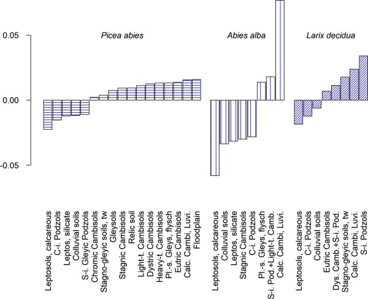

1. [Download : Download high-res image (281KB)](https://ars.els-cdn.com/content/image/1-s2.0-S0378112720314948-gr11_lrg.jpg)
2. [Download : Download full-size image](https://ars.els-cdn.com/content/image/1-s2.0-S0378112720314948-gr11.jpg)

Fig. 11. Parametric coefficients for soil type for *Picea abies* L., *Abies alba* Mill., and *Larix decidua* L. in comparison to the reference group Spodi-Dystric Cambisols. C-i. - climate induced, S-i. - substrate induced, Light-t. - light textured, Heavy-t. - heavy textured, tw-temporarily waterlogged, Pl.s. Gleys - Planosols and Stagnic Gleysols, Calc. Cambi, Luvi - Cambisols and Luvisols, calcareous material.

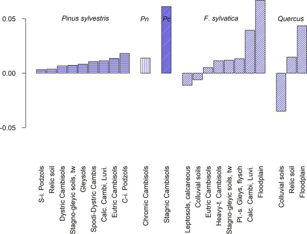

1. [Download : Download high-res image (257KB)](https://ars.els-cdn.com/content/image/1-s2.0-S0378112720314948-gr12_lrg.jpg)
2. [Download : Download full-size image](https://ars.els-cdn.com/content/image/1-s2.0-S0378112720314948-gr12.jpg)

Fig. 12. Parametric coefficients for soil type for *Pinus sylvestris* L., *Pinus nigra* Arnold (Pn), *Pinus cembra* L. (Pc), *Fagus sylvatica* L. (*F. sylvatica*), and *Quercus* spp. in comparison to the reference group Spodi-Dystric Cambisols; except for *Pinus nigra* where the reference group is calcareous Leptosols and for *Quercus* spp. where the reference group is Dystric Cambisols. C-i. - climate induced, S-i. - substrate induced, tw-temporarily waterlogged, Heavy-t. - heavy textured, Pl.s. Gleys - Planosols and Stagnic Gleysols, Calc. Cambi, Luvi - Cambisols and Luvisols, calcareous material.

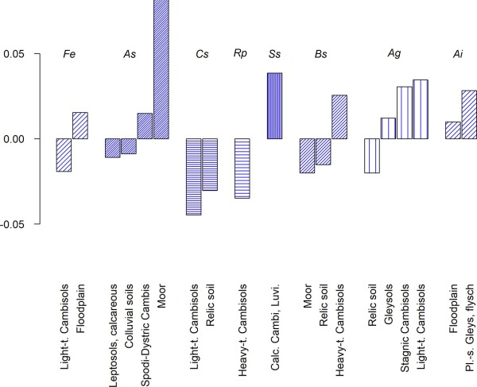

1. [Download : Download high-res image (224KB)](https://ars.els-cdn.com/content/image/1-s2.0-S0378112720314948-gr13_lrg.jpg)
2. [Download : Download full-size image](https://ars.els-cdn.com/content/image/1-s2.0-S0378112720314948-gr13.jpg)

Fig. 13. Parametric coefficients for soil type for *Fraxinus excelsior* L. (Fe), *Acer* spp. (As), *Castanea sativa* Mill. (Cs), *Robinia pseudoacacia* L. (Rp), *Sorbus* spp. (So), *Betulus* spp. (Bs), *Alnus glutinosa* Gaertn. (Ag) and *Alnus incana* Moench (Ai) in comparison to the reference group Spodi-Dystric Cambisols; except *Castanea sativa* where the reference group is Dystric Cambisols, *Robinia pseudoacacia* where the reference group is light-textured Cambisols and *Alnus glutinosa* where the reference group is Stagno-gleyic soils. Light-t. - light textured, Heavy-t. - heavy textured, Cambi. - Cambisols, Calc. Cambi, Luvi - Cambisols and Luvisols, calcareous material, Pl.-s. Gleys., flysch - Planosols and Gleysols on flysch.

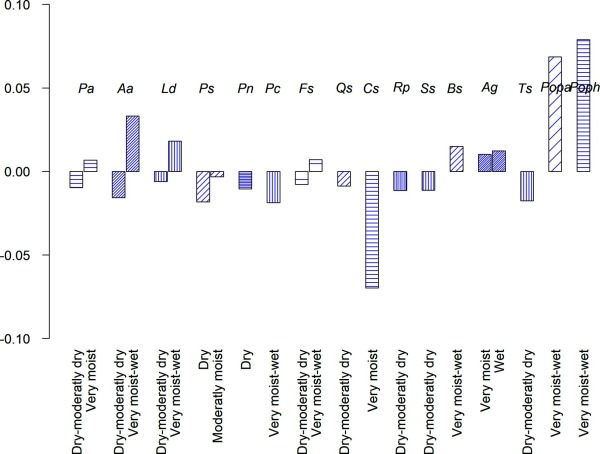

1. [Download : Download high-res image (196KB)](https://ars.els-cdn.com/content/image/1-s2.0-S0378112720314948-gr14_lrg.jpg)
2. [Download : Download full-size image](https://ars.els-cdn.com/content/image/1-s2.0-S0378112720314948-gr14.jpg)

Fig. 14. Parametric coefficients for soil moisture in comparison to the reference group moist soils. Pa - *Picea abies* (L.) Karst., Aa - *Abies alba* Mill., Ld - *Larix decidua* Mill., Ps - *Pinus sylvestris* L., Pn - *Pinus nigra* Arnold, Pc - *Pinus cembra* L., Fs - *Fagus sylvatica* L., Qs - *Quercus* spp., Cs - *Castanea sativa* Mill., Rp - *Robinia pseudoacacia* L., Ss - *Sorbus* spp., Bs - *Betulus* spp., Ag - *Alnus glutinosa* Gaertn., Ts - *Tilia* spp., Popa - *Populus alba* L., Poph - *Populus hybridus*.

### 3.4. Mixture

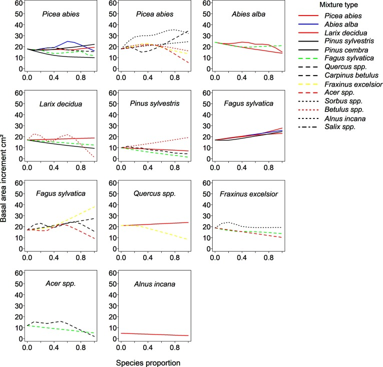

Fig. 15. Basal area increment in cm<sup>2</sup>/year of different tree species over mixture proportion expressed as proportion of the total basal area. The text in the panel refers to the tree species for which the basal area increment was modeled, the legend refers to the tree species the respective species is mixed with.

## 4. Discussion

### 4.1. Size, density, competition and harvesting

One major improvement introduced by this work was the establishment of dedicated models for numerous minor species. All these species were formerly summarized as hardwoods and softwoods, but, as the mean values show, these tree species have distinctly different growth patterns. For many of these species, the data were sufficient, to fit size, density, and competition effects; and for some, even mixture effects could be included. One drawback was that for tree species, such as *Robinia pseudoacacia* or *Populus hybridus*, data were scarce and the resulting model remained very simple. Nevertheless, the data of the Austrian National Forest Inventory in many cases were the best data source available, because for these species, experimental data or data from research experiments, is lacking.

In the new basal area increment model, the term related to size changed little but became somewhat simpler. Here, the GAM framework provided a flexible way of integrating size effects. It can adjust to any type of curve shape, and given the large amount of data, these slightly different shapes were well supported by the data. Various measures of competition were tested, but the different competition indices were almost equivalent. This finding was in line with the findings of Biging and Dobbertin (1995) who showed that differences between different competition measures for the prediction of tree growth were small.

A new variable that was included in the model was the basal area removed, which reflected the response to disturbances and harvesting and the change in competition. This proved significant in 15 out of 22 models. The new variable now facilitates the simulation of harvesting regimes, which is a major field of application of basal area increment models. Even though much effort was devoted to describing different harvesting regimes (for an overview of harvesting models see Weiskittel et al. (2011)), growth response to harvesting was only sometimes included. Here, notable exceptions are the basal area increment models of BWIN and of Silva (Nagel, 2009, Pretzsch and Biber, 2002). Nevertheless, even when a harvesting variable is included, the response to harvesting by individual tree growth models is usually underestimated (e.g. Vospernik et al., 2015). Possible reasons are a lack of extreme harvesting variants in the data (Vospernik et al., 2015) and a clear time trend in thinning response (Bevilacqua et al., 2005). Even though all trees investigated by Bevilacqua et al. (2005) showed positive harvesting reactions, it can take trees up to two years to show a positive reaction. The positive reaction to harvesting in his data was sustained for 22 years, reaching a maximum increase 9 years after harvesting (Bevilacqua et al., 2005). Thus, such distinct temporal patterns cannot be fully captured by 5-year inventory data.

### 4.2. Climate and Site

Recent climate simulations predict a global increase in temperature together with seasonal shifts in precipitation (Intergovernmental Panel on Climate Change (IPCC), IPCC (2013)). Climate warming causes tree species response to changes in temperature and precipitation at the same site. The model term representing climatic effects with long-term-mean temperature and yearly deviations from the long-term-mean temperature, was well adapted to capture and describe such effects for a given site. Moderate climate scenarios for Europe forecast an increase in temperature between 1 °C and 4.5 °C across Europe by the end of the 21st century (Jacob et al., 2014), relative to the period of 1971–2000. Climatic deviations observed in Austria between 1981–2009 for the inventory periods where an average yearly increase in temperature of 1.5 °C and thus, less than the 4.5 °C predicted in more extreme climatic scenarios but in climate simulations this may partly be compensated for by increasing long-term mean temperatures.

Growth responses to temperature and precipitation anomalies were moderate over a wide range of conditions and became more pronounced towards the species distributional limit. This is in line with findings on inter- or intra-annual growth, that focus on growth responses at the dry distribution limit (Weber et al., 2013, van der Maaten, 2012, Vospernik and Nothdurft, 2018) or at high elevation sites (Li et al., 2003, Vospernik and Nothdurft, 2018) and tree ring research is biased towards these extreme habitats (Carrer et al., 2012). Growth reductions reported in these studies for individual dry years are significant and may amount to 40–50% (e.g. Vospernik and Nothdurft, 2018). In a single year, during dry spells, wood formation completely stops but trees can recover quickly afterwards (van der Maaten, 2012). Such extreme years are few, and the 2–4-year average of positive and negative deviations observed in the forest inventory is therefore smoother and less volatile than deviations from increment cores. As a result, correlations of growth to climate are not as clear as from tree ring data from extreme sites. The short duration of such extreme events probably also explains why tree growth is better correlated with temperature and precipitation than with dryness indices. Even though the response to climate is stronger in tree ring data, a major advantage of the inventory data is that it is available across many sites and representative of different regions. In the future, there might be better ways to combine the advantages of both types of data to make use of the full information for analysis and climate predictions.

The site factors elevation, slope, and aspect originally used by Monserud and Sterba (1996) were omitted. These variables are readily available in the inventory data set, but elevation primarily represents a proxy for temperature and precipitation. The adiabatic decrease in temperature with elevation is 0.65 °C and through this physical relationship the two variables are linearly related, unless there are local temperature inversions. The relationship with precipitation is more diffuse, however precipitation also usually increases with elevation, but may differ between inner-alpine locations and locations at the front range Alps (Caccingia et al., 2008). Thus, the distribution of tree species and the elevation of the alpine tree line were strongly affected by climate continentality (Caccingia et al., 2008) and this was also confirmed by the model results for *Larix decidua* and *Pinus cembra*. These two species showed a decrease in growth with increasing precipitation, reflecting their sensitivity to long snow cover and snow molt infection in the case of *Pinus cembra*. It is also well-known that with slope and aspect, irradiation may change. Irradiation is not yet included in the model but might be added when the respective data become more readily available.

Assessing the impact of climate on tree growth requires a good knowledge of climatic, edaphic and synecological controls acting upon each individual tree species. Soil type and/or soil moisture is often included in growth models (e.g. Monserud and Sterba, 1996, Schmidt and Albert, 2010, Pretzsch and Biber, 2002), and proved significant also in this modeling approach. Probably the largest differences in tree growth were caused by the parent material of soils. Calcareous Leptosols, which are poor in nutrients and have a low water-holding capacity showed the strongest negative impact on basal area increment. Most likely these soils are also classified as dry, so that effects for soil type and soil moisture taken together result in an even stronger decreases than would be inferred from the soil type itself. Here, the causal variables were soil water holding capacity and nutrient availability. These variables are for example included in the site index model of Schmidt and Albert (2010). If this information becomes available for the data from the Austrian National Forest Inventory, the inclusion of these variables might further refine the basal area increment model in the future.

The aim of this research was to develop a simple and transferable model and variables were therefore restricted to those, which are readily available for different data sets. Thus, variables such as growth district, vegetation type, or the thickness of F-humus and H-humus, that were included by Monserud and Sterba (1996) were also omitted. This may result in lower *R*<sup>*2*</sup>-values but facilitates the application of the model and permits an application of the model outside Austria in Central Europe, where similar tree species occur, and comparable climatic conditions exist.

### 4.3. Mixture

Management of mixed woods is advocated as an effective adaptation strategy to increase ecosystem resilience in the context of climate change. Including both mixture and climate effects in the basal area increment model enables evaluation of these effects in tree growth simulations. Different tree species can facilitate or compete with each other (Kelty et al., 1992) and mixture effects can be both positive and negative (Kelty et al., 1992), but positive mixture effects prevail (Pretzsch and Schütze, 2009). Mixture effects arise from a complementary resource use of different tree species due to differences in crown (Kelty et al., 1992, Pretzsch and Schütze, 2009, Pretzsch, 2014) and root morphology (Kelty et al., 1992, Schmid and Kazda, 2002) and the resulting light use (Pretzsch, 2014) and water and nutrient (Thelina et al., 2002) uptake. In addition, mixture effects have also been also reported to originate from the fact that different tree species influence soil water conditions (Schume et al., 2002) and humus formation (Aubert et al., 2006) in different ways. According to ecological niche theory, mixture effects are particularly strong for tree species, which are highly complementary. Large gains in increment are reported for combining light-demanding with shade-tolerant (Zöhrer, 1969) and shallow with deep-rooting species (Schmid and Kazda, 2002), or slim crowned-tree species with more lateral species (Pretzsch and Schütze, 2009). Gains in such mixtures can amount to 30%, whereas the benefit from mixing more similar tree species, e.g. *Quercus* spp.-*Pinus sylvestris* is only 7% or 9% (Pretzsch et al., 2020).

The results from our modeling effort confirmed the ecological niche theory in that the mixtures of species with similar traits did not significantly alter growth, even though the number of observations in the data set were large. In diverse mixtures, at individual tree level either one of the two species gained at the expense of the other species or both species seemed to benefit. An example of the first pattern is the mixture of *Picea abies* and *Fagus sylvatica*. The individual tree growth of *Fagus sylvatica* increased with the admixture of *Picea abies*, whereas the opposite was true for *Picea abies*, which responded with decreased individual tree growth. This pattern corroborated studies on the individual tree growth of these two species, where the growth of *Picea abies* was more strongly reduced in mixture than growth of *Fagus sylvatica* (Nothdurft and Engel, 2020), but at the stand level the net effect was often positive for this well studied mixture, possibly also due to differences in packing density for these two species (Pretzsch and Schütze, 2009). The latter pattern, with positive effects for both tree species, was observed for *Larix decidua* and *Picea abies*. Here, the mixture was positive for both species at the individual tree level, confirming the results of Zöhrer (1969). From the inventory data, mixture effects for rare species were also derived. To the best of our knowledge, mixture effects for *Sorbus* spp. have not been investigated before. This study could confirm mixture effects for *Fraxinus excelsior*, *Fagus sylvatica*, *Picea abies* and *Quercus* spp..

Almost all the mixture effects found, varied with species proportion. This is in line with findings from (e.g. Huber et al., 2014). Other mixture effects frequently reported variations with stand age, density, and site (Pretzsch and Schütze, 2009, Huber et al., 2014). This was not confirmed in this modeling approach, even though the respective interactions were introduced in the models. This is partly due to too few observations to fit such effects even from a large inventory data set, and partly due to too large a number of confounding variables in the data set. With the addition of interactions, the very flexible GAM-framework seemed to trace smaller patterns in the data rather than general growth patterns.

## 5. Conclusions

The model predicted basal area increment based on size, competition, density, climate, harvesting and disturbances, edaphic factors, and mixture effects and was therefore based on important tree growth factors. In the model approach, proxy-variables were avoided and instead the causal variables were integrated, whenever possible in order to describe general growth patterns rather than particularities of the data. The most difficult component to include in the basal area increment model was the site component, since this term summarizes a multitude of environmental factors. Moreover, the large number of possible site factors made it difficult to find a reasonable model that is adequate for all sites represented by the entire forest inventory. Limiting factors for growth may differ between sites, and regional models for tree growth might be needed. In particular, little is still known about tree growth responses on non-extreme sites, which represent the majority of forest sites. Novel in this study is the inclusion of climatic effects as long-term means, representing the site component of climate, and deviations thereof representing weather conditions and/or climatic change. This approach is a step forward in understanding the climate-growth relationship in inventory data, but probably even better models can be found in the future, since yearly or daily increment data show better correlations of climate and growth. This is because this type of data has a better temporal resolution but does not usually encompass a multitude of sites necessary for inferences that include large areas. Thus it might be possible to obtain better models by combining the two types of data, and model distinct temporal growth patterns from year-ring data, while at the same time preserving the advantages of a large statistical data set which assures robust mean predictions. The same may apply to disturbances, which also have distinct temporal patterns. The new modeling approach is better adapted to the simulation of tree growth response to climate change and to mitigating mixture effects, since both effects are explicitly integrated in the model. Generalized additive models provide very flexible tools for growth modeling, with great potential for modelling complex relationships, but additional care has to be taken to avoid model overfitting.

## CRediT authorship contribution statement

**Sonja Vospernik:** Support funding acquisition, Conceptualization, Formal analysis, Investigation, Methodology, Visualization, Writing - original draft, Writing - review and editing.

## Declaration of Competing Interest

The authors declare that they have no known competing financial interests or personal relationships that could have appeared to influence the work reported in this paper.

## Acknowledgments

This study was carried out in the context of the project REFORM under the umbrella of the ERA-NET project Sumforest which was locally funded by the Austrian Federal Ministry of Agriculture, Forestry, Environment and Water Management (project number 101199). Many thanks to the “Forschungszentrum für Wald und Naturgefahren“, in particular to Klemens Schadauer for making the ANFI data available for this research. The many helpful review comments greatly improved this manuscript.

## References

**Akaike, 1973**

Akaike, H., 1973. Information theory as an extension of the maximum likelihood principle. In: Petrov, B.N., Csaksi, F. (Eds.), Second international symposium on information theory Akademiai Kiado Budapest, pp. 267–281.

Google Scholar

**Aubert et al., 2006**

M. Aubert, P. Margerie, A. Ernoult, T. Decaëns, F. Bureau

**Variability and heterogeneity of humus forms at stand level: Comparison between pure beech and mixed beech-hornbeam forest**

Ann. For. Sci., 63 (2) (2006), pp. 177-188, 10.1051/forest:2005110

[CrossRef](https://doi.org/10.1051/forest:2005110)[View Record in Scopus](https://www.scopus.com/inward/record.url?eid=2-s2.0-33646557325&partnerID=10&rel=R3.0.0)Google Scholar

**Bevilacqua et al., 2005**

E. Bevilacqua, D. Puttock, T.J. Blake, D. Burgess

**Long-term differential stem growth response in mature eastern white pine following release from competition**

Can. J. For. Res., 35 (3) (2005), pp. 511-520, 10.1139/x04-198

[CrossRef](https://doi.org/10.1139/x04-198)[View Record in Scopus](https://www.scopus.com/inward/record.url?eid=2-s2.0-22144488113&partnerID=10&rel=R3.0.0)Google Scholar

**Biging and Dobbertin, 1992**

G.S. Biging, M. Dobbertin

**A comparison of distance-dependent competition measures for height and basal area growth of individual conifer trees**

Forest Sci., 38 (3) (1992), pp. 695-720, 10.1093/forestscience/38.3.695

Google Scholar

**Biging and Dobbertin, 1995**

G.S. Biging, M. Dobbertin

**Evaluation of competition indices in individual tree growth models**

Forest Sci., 41 (2) (1995), pp. 360-377, 10.1093/forestscience/41.2.360

[Google Scholar](https://scholar.google.com/scholar_lookup?title=Evaluation%20of%20competition%20indices%20in%20individual%20tree%20growth%20models&publication_year=1995&author=G.S.%20Biging&author=M.%20Dobbertin)

**Bitterlich, 1948**

Bitterlich

**Die Winkelzählprobe**

Allgemeine Forst- und Holzwirtschaftliche Zeitung., 59 (1/2) (1948), pp. 4-5

[View Record in Scopus](https://www.scopus.com/inward/record.url?eid=2-s2.0-0002227563&partnerID=10&rel=R3.0.0)[Google Scholar](https://scholar.google.com/scholar_lookup?title=Die%20Winkelz%C3%A4hlprobe&publication_year=1948&author=Bitterlich)

**Brauner et al., 2005**

M. Brauner, W. Weinmeister, P. Agner, S. Vospernik, B. Hoesle

**Forest management decision support for evaluating forest protection effects against rockfall**

For. Ecol. Manage., 207 (1–2) (2005), pp. 75-85, 10.1016/j.foreco.2004.10.018

[Article](https://www.sciencedirect.com/science/article/pii/S0378112704007285)[Download PDF](https://www.sciencedirect.com/science/article/pii/S0378112704007285/pdfft?md5=819169784c732802f9aa4474608bd4e4&pid=1-s2.0-S0378112704007285-main.pdf)[View Record in Scopus](https://www.scopus.com/inward/record.url?eid=2-s2.0-14644439948&partnerID=10&rel=R3.0.0)Google Scholar

**Bueckling et al., 2017**

A. Bueckling, P.H. Martin, C.D. Canham

**Climate and competition effects on tree growth in Rocky Mountain forests**

J. Ecol., 105 (2017), pp. 1636-1647, 10.1111/1365-2745.12782

Google Scholar

**Caccingia et al., 2008**

M. Caccingia, C. Andreis, S. Armiraglio, G. Leonelli, M. Pelfini, D. Sala

**Climate continentality and treeline species distribution in the Alps**

Plant Biosyst.- Int. J. Dealing Aspects Plant Biol., 142 (1) (2008), pp. 66-78, 10.1080/11263500701872416

Google Scholar

**Canham et al., 1994**

C.D. Canham, A.C. Finzi, S.W. Pacala, D.H. Burbank

**Causes and consequences of resource heterogeneity in forests: interspecific variation in light transmission by canopy trees**

Can. J. For. Res., 24 (2) (1994), pp. 337-349, 10.1139/x94-046

[CrossRef](https://doi.org/10.1139/x94-046)[View Record in Scopus](https://www.scopus.com/inward/record.url?eid=2-s2.0-0028180423&partnerID=10&rel=R3.0.0)Google Scholar

**Carrer et al., 2012**

M. Carrer, R. Motta, P. Nola

**Significant mean and extreme climate sensitivity of Norway spruce at mid-elevation mesic sites in the Alps**

PLoSOne, 7 (11) (2012), p. e50755, 10.1371/journal.pone.0050755

[CrossRef](https://doi.org/10.1371/journal.pone.0050755)[View Record in Scopus](https://www.scopus.com/inward/record.url?eid=2-s2.0-84870478581&partnerID=10&rel=R3.0.0)Google Scholar

**Martonne, 1926**

de Martonne

**Une novel fonction climatologique. L’indice d’aridité. A new climatologic function. An index of aridity**

Météorologie, 21 (1926), pp. 449-458

[View Record in Scopus](https://www.scopus.com/inward/record.url?eid=2-s2.0-0000959060&partnerID=10&rel=R3.0.0)[Google Scholar](https://scholar.google.com/scholar?q=Une%20novel%20fonction%20climatologique.%20Lindice%20daridit%C3%A9.%20A%20new%20climatologic%20function.%20An%20index%20of%20aridity)

**Debeljak et al., 2001**

M. Debeljak, S. Džzeroski, K. Jerina, A. Kobler, M. Adamič

**Habitat suitability modelling for red deer (Cervus elaphus L.) in South-central Slovenia with classification trees**

Ecol. Model., 138 (2001), pp. 321-330, 10.1016/S0304-3800(00)00411-7

[Article](https://www.sciencedirect.com/science/article/pii/S0304380000004117)[Download PDF](https://www.sciencedirect.com/science/article/pii/S0304380000004117/pdfft?md5=30ecd9b2bccb9b9609c3b7080711334c&pid=1-s2.0-S0304380000004117-main.pdf)[View Record in Scopus](https://www.scopus.com/inward/record.url?eid=2-s2.0-0035867042&partnerID=10&rel=R3.0.0)[Google Scholar](https://scholar.google.com/scholar?q=Habitat%20suitability%20modelling%20for%20red%20deer%20%20in%20South-central%20Slovenia%20with%20classification%20trees)

**Efthymiadis et al., 2006**

D. Efthymiadis, P.D. Jones, K.R. Briffa, I. Auer, R. Böhm, W. Schöner, Ch. Frei, J. Schmidili

**Construction of a 10-min-gridded precipitation data set for the Greater Alpine Region for 1800–2003**

J. Geophys. Res., 111 (D01105) (2006), pp. 1-22, 10.1029/2005JD006120

[Google Scholar](https://scholar.google.com/scholar?q=Construction%20of%20a%2010-min-gridded%20precipitation%20data%20set%20for%20the%20Greater%20Alpine%20Region%20for%2018002003)

**Engel et al., 2020**

M. Engel, S. Vospernik, M. Toïgo, X. Morin, A. Tomao, C. Trotta, M. Steckel, A. Barbati, A. Nothdurft, H. Pretzsch, M. del Rio, J. Skrzyszewski, Q. Ponette, M. Löf, Ā. Jansons, G. Brazaitis

**Brazaitis, G. 2020. Simulating the effects of thinning and species mixing on stands of oak (Quercus petrea (Matt.) Liebl./ Quercus robur L.) and pine (Pinus sylvestris L.) across Europe**

Ecolog. Modell. (2020)

Google Scholar

**Forstliche Bundesversuchsanstalt, 1994**

Forstliche Bundesversuchsanstalt 1994, 1994. Instruktionen für die Feldarbeiten der Österreichischen Forstinventur 1992–1996 Field manual of the Austrian National Forest Inventory 1992–1996 Forstliche Bundesversuchsanstalt Wien 194 pp.

Google Scholar

**Greene, 2001**

Greene, W., 2001. Fixed and random effects in nonlinear models. NYU working paper. No. Ec-01-01. 48 pp.

[Google Scholar](https://scholar.google.com/scholar?q=Greene,%20W.,%202001.%20Fixed%20and%20random%20effects%20in%20nonlinear%20models.%20NYU%20working%20paper.%20No.%20Ec-01-01.%2048%20pp.)

**Harring and Liu, 2016**

J.R. Harring, J. Liu

**A comparison of estimation methods for nonlinear mixed effects models under model misspecification and data sparseness: A simulation study**

Stat. Methods, 15 (1) (2016), pp. 539-569, 10.22237/jmasm/1462076760

[CrossRef](https://doi.org/10.22237/jmasm/1462076760)[View Record in Scopus](https://www.scopus.com/inward/record.url?eid=2-s2.0-84975261114&partnerID=10&rel=R3.0.0)Google Scholar

**Hasenauer, 1994**

Hasenauer, H., 1994. Ein Einzelbaumwachstumssimulator für ungleichaltrige Fichten-, Kiefern-, und Buchen-Fichtenmischbestände. An individual-tree growth simulator for uneven-aged and mixed Norway spruce, Scots pine and European beech stands. Forstliche Schriftenreihe Universität für Bodenkultur Wien 8. Österreichische Gesellschaft für Waldökosystemforschung und experimentelle Baumforschung. Wien.: 152 pp.

Google Scholar

**Hasenauer, 2000**

H. Hasenauer

**Die simultanen Eigenschaften von Waldwachstumsmodellen. Forest growth models fitted by simultaneous regression**

Paul Parey Verlag, Berlin (2000), p. 131

Google Scholar

**Hasenauer and Monserud, 1996**

H. Hasenauer, R.A. Monserud

**A crown model for Austrian Forests**

For. Ecol. Manage., 84 (1996), pp. 49-60, 10.1016/0378-1127(96)03768-1

[Article](https://www.sciencedirect.com/science/article/pii/0378112796037681)[Download PDF](https://www.sciencedirect.com/science/article/pii/0378112796037681/pdf?md5=f663a006b2a56ef801846fdbef5f064b&pid=1-s2.0-0378112796037681-main.pdf)[View Record in Scopus](https://www.scopus.com/inward/record.url?eid=2-s2.0-0030201324&partnerID=10&rel=R3.0.0)[Google Scholar](https://scholar.google.com/scholar_lookup?title=A%20crown%20model%20for%20Austrian%20Forests&publication_year=1996&author=H.%20Hasenauer&author=R.A.%20Monserud)

**Hiebl et al., 2009**

J. Hiebl, I. Auer, R. Böhm, W. Schöner, M. Maugeri, G. Lentini, J. Spinoni, M. Brunett, T. Nanni, M.P. Tadi, Z. Bihari, M. Dolinar, G. Müller-Westermeier

**A high-resolution 1961-1990 monthly temperature climatology for the greater Alpine region**

Meteorol. Z., 18 (5) (2009), pp. 507-530, 10.1127/0941-2948/2009/0403

[CrossRef](https://doi.org/10.1127/0941-2948/2009/0403)[View Record in Scopus](https://www.scopus.com/inward/record.url?eid=2-s2.0-77949451091&partnerID=10&rel=R3.0.0)Google Scholar

**Hastie and Tibshirani, 1990**

T.J. Hastie, R.J. Tibshirani

**Generalized Additive Models**

Chapman & Hall/CRC, New York/Boca Raton (1990)

[Google Scholar](https://scholar.google.com/scholar_lookup?title=Generalized%20Additive%20Models&publication_year=1990&author=T.J.%20Hastie&author=R.J.%20Tibshirani)

**Huber et al., 2014**

M.O. Huber, H. Sterba, L. Bernhard

**Site conditions and definition of compositional proportion modify mixture effects in Picea abies – Abies alba stands**

Can. J. For. Res., 44 (2014), pp. 1281-1291, 10.1139/cjfr-2014-0188

[CrossRef](https://doi.org/10.1139/cjfr-2014-0188)[View Record in Scopus](https://www.scopus.com/inward/record.url?eid=2-s2.0-84907519680&partnerID=10&rel=R3.0.0)[Google Scholar](https://scholar.google.com/scholar?q=Site%20conditions%20and%20definition%20of%20compositional%20proportion%20modify%20mixture%20effects%20in%20Picea%20abies%20%20Abies%20alba%20stands)

**IPCC, 2013**

IPCC, 2013. Climate Change 2013: The Physical Science Basis. Contribution of Working Group I to the Fifth Assessment Report of the Intergovernmental Panel on Climate Change. Cambridge University Press, Cambridge, United Kingdom and New York, NY, USA.

Google Scholar

**Jacob et al., 2014**

D. Jacob, J. Petersen, B. Eggert, *et al.*

**EURO-CORDEX: New high-resolution climate change projections for European impact research**

Reg. Environ. Change, 14 (2) (2014), pp. 563-578, 10.1093/treephys/tpu096

[CrossRef](https://doi.org/10.1007/s10113-013-0499-2)[View Record in Scopus](https://www.scopus.com/inward/record.url?eid=2-s2.0-84897025478&partnerID=10&rel=R3.0.0)Google Scholar

**Kahn, 1994**

M. Kahn

**Modellierung der Höhenentwicklung ausgewählter Baumarten in Abhängigkeit vom Standort. Modelling the height development of selected tree species depending on site**

Forstlicher Forschungsbericht München, 141 (1994), p. 203

Google Scholar

**Kelty et al., 1992**

Kelty, M.J., Larson, Bruce C., Oliver, Chadwick D. (Eds.) 1992. The Ecology and Silviculture of Mixed-Species Forests. Forestry Science40 Springer Netherlands, pp. 287. https://doi.org/10.1007/978-94-015-8052-6.

Google Scholar

**Kindermann, 2010**

G. Kindermann

**Eine klimasensitive Weiterentwicklung des Kreisflächenzuwachsmodells aus Prognaus. A climate sensitive enhancement of the individual tree growth model of Prognaus**

Centralblatt für das gesamte Forstwesen, 127 (3/4) (2010), pp. 147-178

[View Record in Scopus](https://www.scopus.com/inward/record.url?eid=2-s2.0-78651365751&partnerID=10&rel=R3.0.0)Google Scholar

**Krajicek et al., 1961**

J.E. Krajicek, K.E. Brinkmann, S.F. Gingrich

**Crown competition - a measure of density**

Forest Sci., 7 (1961), pp. 35-42

[Google Scholar](https://scholar.google.com/scholar_lookup?title=Crown%20competition%20-%20a%20measure%20of%20density&publication_year=1961&author=J.E.%20Krajicek&author=K.E.%20Brinkmann&author=S.F.%20Gingrich)

**Lang and Laird, 1989**

N. Lang, N.M. Laird

**The effect of covariance structure on variable estimation in balanced growth curve models with random parameters**

J. Am. Stat. Assoc., 84 (105) (1989), pp. 241-247, 10.1080/01621459.1989.10478761

[CrossRef](https://doi.org/10.1007/978-3-642-83771-5_50)[View Record in Scopus](https://www.scopus.com/inward/record.url?eid=2-s2.0-84883257191&partnerID=10&rel=R3.0.0)Google Scholar

**Li et al., 2003**

M.H. Li, J. Yang, N. Kräuchi

**Growth response of Picea abies and Larix decidua to elevation in subalpine area of Tyrol**

Austria Can. J. For. Res., 33 (4) (2003), pp. 653-662, 10.1139/x02-202

[View Record in Scopus](https://www.scopus.com/inward/record.url?eid=2-s2.0-0037534012&partnerID=10&rel=R3.0.0)Google Scholar

**Maguire et al., 1991**

D.A. Maguire, J.A. Kershaw, D.W. Hann

**Predicting the effects of silvicultural regime on branch size and crown wood core in Douglas-Fir**

Forest Sci., 37 (1991), pp. 1409-1428, 10.1093/forestscience/37.5.1409

[View Record in Scopus](https://www.scopus.com/inward/record.url?eid=2-s2.0-0000520422&partnerID=10&rel=R3.0.0)Google Scholar

**McCullagh and Nelder, 1989**

P. McCullagh, J.A. Nelder

**Generalized Linear Models**

(2nd ed.), Chapman and Hall (1989)

[Google Scholar](https://scholar.google.com/scholar_lookup?title=Generalized%20Linear%20Models&publication_year=1989&author=P.%20McCullagh&author=J.A.%20Nelder)

**McKee et al., 1993**

McKee, T.B., Doesken, N.J., Kleist, J., 1993. The relationship of drought frequency and duration to time scale. In: Proceedings of the Eighth Conference on Applied Climatology Anaheim, California, 17–22 January 1993 Boston, American Meteorological Society, pp. 179–184.

Google Scholar

**Monserud and Sterba, 1996**

R.A. Monserud, H. Sterba

**A basal area increment model for individual trees growing in even- and unevenaged forest stands in Austria**

For. Ecol. Manage., 80 (1996), pp. 57-80, 10.1016/0378-1127(95)03638-5

[Article](https://www.sciencedirect.com/science/article/pii/0378112795036385)[Download PDF](https://www.sciencedirect.com/science/article/pii/0378112795036385/pdf?md5=3a2639e1233c458c18f5d4f853d461af&pid=1-s2.0-0378112795036385-main.pdf)[View Record in Scopus](https://www.scopus.com/inward/record.url?eid=2-s2.0-0029668336&partnerID=10&rel=R3.0.0)Google Scholar

**Monserud and Sterba, 1999**

R.A. Monserud, H. Sterba

**Modelling individual tree mortality for Austrian forest species**

For. Ecol. Manage., 113 (1999), pp. 109-123, 10.1016/S0378-1127(98)00419-8

[Article](https://www.sciencedirect.com/science/article/pii/S0378112798004198)[Download PDF](https://www.sciencedirect.com/science/article/pii/S0378112798004198/pdfft?md5=c1f535b268f00f2e2c5879c015da6c88&pid=1-s2.0-S0378112798004198-main.pdf)[View Record in Scopus](https://www.scopus.com/inward/record.url?eid=2-s2.0-0033601728&partnerID=10&rel=R3.0.0)[Google Scholar](https://scholar.google.com/scholar_lookup?title=Modelling%20individual%20tree%20mortality%20for%20Austrian%20forest%20species&publication_year=1999&author=R.A.%20Monserud&author=H.%20Sterba)

**Nachtmann, 2006**

G. Nachtmann

**Height increment models for individual trees in Austria depending on site and competition**

Austrian J. For. Sci., 123 (2006), pp. 199-222

[View Record in Scopus](https://www.scopus.com/inward/record.url?eid=2-s2.0-33947176024&partnerID=10&rel=R3.0.0)[Google Scholar](https://scholar.google.com/scholar_lookup?title=Height%20increment%20models%20for%20individual%20trees%20in%20Austria%20depending%20on%20site%20and%20competition&publication_year=2006&author=G.%20Nachtmann)

**Nagel, 2009**

Nagel, J., 2009. Waldwachtumssimulation mit dem Java Software Paket TreeGross Forest growth simulation with the Java software package TreeGross Nordwestdeutsche Forstliche Versuchsanstalt, pp. 62.

Google Scholar

**Nothdurft, 2013**

A. Nothdurft

**Spatio-temporal prediction of tree mortality based on long-term sample plots, climate change scenarios and parametric frailty modeling**

For. Ecol. Manage., 291 (2013), pp. 43-54, 10.1016/j.foreco.2012.11.028

[Article](https://www.sciencedirect.com/science/article/pii/S0378112712007049)[Download PDF](https://www.sciencedirect.com/science/article/pii/S0378112712007049/pdfft?md5=f140fb2e42b856c46ef90d78cd632fdd&pid=1-s2.0-S0378112712007049-main.pdf)[View Record in Scopus](https://www.scopus.com/inward/record.url?eid=2-s2.0-84871874919&partnerID=10&rel=R3.0.0)Google Scholar

**Nothdurft et al., 2012**

A. Nothdurft, T. Wolf, A. Ringeler, J. Böhner, J. Saborowski

**Spatio-temporal prediction of site index based on forest inventories and climate change scenarios**

For. Ecol. Manage., 279 (2012), pp. 97-111, 10.1016/j.foreco.2012.05.018

[Article](https://www.sciencedirect.com/science/article/pii/S0378112712002873)[Download PDF](https://www.sciencedirect.com/science/article/pii/S0378112712002873/pdfft?md5=09d00b6b6fbe310295ca4afc0dbb483b&pid=1-s2.0-S0378112712002873-main.pdf)[View Record in Scopus](https://www.scopus.com/inward/record.url?eid=2-s2.0-84862661129&partnerID=10&rel=R3.0.0)Google Scholar

**Nothdurft and Engel, 2020**

A. Nothdurft, M. Engel

**Climate sensitivity and resistance under pure and mixed-stand scenarios in Lower Austria evaluated with distributed lag models and penalized regression splines for tree-ring time series**

Eur. J. Forest Res., 139 (2020), pp. 189-211, 10.1007/s10342-019-01234-x

[CrossRef](https://doi.org/10.1007/s10342-019-01234-x)[View Record in Scopus](https://www.scopus.com/inward/record.url?eid=2-s2.0-85073987620&partnerID=10&rel=R3.0.0)Google Scholar

**Pokharel and Froese, 2009**

B. Pokharel, R.E. Froese

**Representing site productivity in the basal increment model of FVS-Ontario**

For. Ecol. Manage., 258 (2009), pp. 657-666, 10.1016/j.foreco.2009.04.040

[Article](https://www.sciencedirect.com/science/article/pii/S0378112709003314)[Download PDF](https://www.sciencedirect.com/science/article/pii/S0378112709003314/pdfft?md5=270995960f52c8cc07c39217f95a1695&pid=1-s2.0-S0378112709003314-main.pdf)[View Record in Scopus](https://www.scopus.com/inward/record.url?eid=2-s2.0-67649998499&partnerID=10&rel=R3.0.0)[Google Scholar](https://scholar.google.com/scholar_lookup?title=Representing%20site%20productivity%20in%20the%20basal%20increment%20model%20of%20FVS-Ontario&publication_year=2009&author=B.%20Pokharel&author=R.E.%20Froese)

**Pretzsch, 2002**

Pretzsch, H., 2002. Application and evaluation of the growth simulator Silva 2.2 for forest stands, forest estates and large regions. Forstwissenschaftliches Zentralblatt, 121, 28–51.

Google Scholar

**Pretzsch, 2014**

H. Pretzsch

**Canopy space filling and tree crown morphology in mixed-species stands compared with monocultures**

For. Ecol. Manage., 327 (1) (2014), pp. 251-264, 10.1016/S0378-1127(02)00047-6

[Article](https://www.sciencedirect.com/science/article/pii/S0378112714002667)[Download PDF](https://www.sciencedirect.com/science/article/pii/S0378112714002667/pdfft?md5=767419b681ca9d4f8d46f6468855dd72&pid=1-s2.0-S0378112714002667-main.pdf)[View Record in Scopus](https://www.scopus.com/inward/record.url?eid=2-s2.0-84905008292&partnerID=10&rel=R3.0.0)Google Scholar

**Pretzsch and Biber, 2002**

H. Pretzsch, P. Biber, Durský

**The single tree-based stand simulator SILVA: construction, application and evaluation**

For. Ecol. Manage., 162 (2002), pp. 3-21, 10.1016/S0378-1127(02)00047-6

[Article](https://www.sciencedirect.com/science/article/pii/S0378112702000476)[Download PDF](https://www.sciencedirect.com/science/article/pii/S0378112702000476/pdfft?md5=87880bae4e0792f7b0842ebaa95037f1&pid=1-s2.0-S0378112702000476-main.pdf)[View Record in Scopus](https://www.scopus.com/inward/record.url?eid=2-s2.0-0036607187&partnerID=10&rel=R3.0.0)Google Scholar

**Pretzsch and Schütze, 2009**

H. Pretzsch, G. Schütze

**Transgressive overyielding in mixed compared with pure stands of Norway spruce and European beech in Central Europe: evidence on stand level and explanation on individual tree level**

Eur. J. Forest Res., 128 (2) (2009), pp. 183-204, 10.1007/s10342-008-0215-9

[CrossRef](https://doi.org/10.1007/s10342-008-0215-9)[View Record in Scopus](https://www.scopus.com/inward/record.url?eid=2-s2.0-61349153734&partnerID=10&rel=R3.0.0)Google Scholar

**Pretzsch et al., 2020**

H. Pretzsch, M. Steckel, M. Heym, P. Biber, C. Ammer, M. Ehbrecht, K. Bielak, F. Bravo., C. Ordóñez, C. Collet, F. Vast, L. Droessler, G. Brazaitis, A. Jansons, L. Coll, M. Löf, J. Aldea, N. Korboulewsky, D.O.J. Reventlow, A. Nothdurft, M. Engel, M. Pacht, J. Skrzyszewskj, M. Pardos, Q. Ponette, R. Sitko, M. Fabrika, M. Svoboda, J. Černý, B. Wolff, R. Ruiz-Peinado, M. del Rio

**Stand growth and structure of mixed-species and monospecific stands of Scots pine (Pinus sylvestris) L. and oak (Q. robur L., Quercus petraea (MATT.) LIEBL.) analysed along a productivity gradient through Europe**

European Journal of Forest Research, 139 (2020), pp. 349-367, 10.1007/s10342-019-01233-y

[CrossRef](https://doi.org/10.1007/s10342-019-01233-y)[View Record in Scopus](https://www.scopus.com/inward/record.url?eid=2-s2.0-85072573425&partnerID=10&rel=R3.0.0)Google Scholar

**Reineke, 1993**

L.H. Reineke

**Perfecting a stand-density index for even-aged forests**

J. Agric. Res., 46 (1993), pp. 627-638

[Google Scholar](https://scholar.google.com/scholar_lookup?title=Perfecting%20a%20stand-density%20index%20for%20even-aged%20forests&publication_year=1993&author=L.H.%20Reineke)

**Roloff and Grundmann, 2009**

Roloff, A., Grundmann, B., 2009. Bewertung von Waldbaumarten anhand der KlimaArtenMatrix Evaluation of tree species with a climate - species matrix AFZ/Der. Wald 63(20), 1086–1088.

Google Scholar

**R Core Team, 2018**

R Core Team

**R: a language and environment for statistical computing**

R Foundation for Statistical Computing, Vienna, Austria (2018)

[https://www.R-project.org/](https://www.r-project.org/)

[Google Scholar](https://scholar.google.com/scholar_lookup?title=R%3A%20a%20language%20and%20environment%20for%20statistical%20computing&publication_year=2018&author=R%20Core%20Team)

**Schmid and Kazda, 2002**

I. Schmid, M. Kazda

**Root distribution of Norway spruce in monospecific and mixed stands on different soils**

For. Ecol. Manage., 159 (1–2) (2002), pp. 37-47, 10.1016/S0378-1127(01)00708-3

[Article](https://www.sciencedirect.com/science/article/pii/S0378112701007083)[Download PDF](https://www.sciencedirect.com/science/article/pii/S0378112701007083/pdfft?md5=0cf963a28a1a2cd6e191e1768229ede3&pid=1-s2.0-S0378112701007083-main.pdf)[View Record in Scopus](https://www.scopus.com/inward/record.url?eid=2-s2.0-0036534032&partnerID=10&rel=R3.0.0)Google Scholar

**Schmidt and Hansen, 2007**

Schmidt, M., Hansen, J., 2007. Validierung der Durchmeserzuwachsprognosen des Wachstumssimulators BWINPro 7.0 für Fichte und Buche für den Bereich der Bundesländer. Evaluation of diameter increment prediction for the individual tree growth simulator BWINPro 7.0 for Norway spruce and European beech for different regions. In: Nagel, J. (Ed.), Sekt. Ertragskd. Jahrestagung 2007, Alsfeld. pp. 164–179.

Google Scholar

**Schume et al., 2002**

H. Schume, G. Jost, H. Hager

**Soil water depletion and recharge patterns in mixed and pure forest stands of European beech and Norway spruce**

J. Hydrol., 289 (1–4) (2002), pp. 258-274, 10.1016/j.jhydrol.2003.11.036

Google Scholar

**Schmidt and Albert, 2010**

Schmidt, M., Albert, M. 2010. A climate-sensitive modelling of site-productivity relationships for Norway spruce (Picea abies (L.) Karst) and Common beech (Fagus sylvatica L.) Forest ecology and management 259, 739–749, doi: 10.1016/j.foreco.2009.04.039.

Google Scholar

**Stephenson et al., 2014**

N.L. Stephenson, A.J. Das, R. Condit, S.E. Russo, P.J. Baker, N.G. Beckman, D.A. Coomes, E.R. Lines, W.K. Morris, N. Rüger, E. Álvarez, C. Blundo, S. Bunyavejchewin, G. Chuyong, S.J. Davies, Á. Duque, C.N. Ewango, O. Flores, J.F. Franklin, H.R. Grau, Z. Hao, M.E. Harmon, S.P. Hubbell, D. Kenfack, Y. Lin, J.-R. Makana, A. Malizia, L.R. Malizia, R.J. Pabst, N. Pongpattananurak, S.-H. Su, I.-F. Sun, S. Tan, D. Thomas, P.J. van Mantgem, X. Wang, S.K. Wiser, M.A. Zavala

**Rate of tree carbon accumulation increases continuously with tree size**

Nature, 507 (2014), pp. 90-93, 10.1038/nature12914

[CrossRef](https://doi.org/10.1038/nature12914)[View Record in Scopus](https://www.scopus.com/inward/record.url?eid=2-s2.0-84895891939&partnerID=10&rel=R3.0.0)Google Scholar

**Thelina et al., 2002**

G. Thelina, U. Rosengrena, I. Callesen, M. Ingerslev

**The nutrient status of Norway spruce in pure and in mixed-species stands**

For. Ecol. Manage., 160 (1–3) (2002), pp. 115-125, 10.1016/S0378-1127(01)00464-9

Google Scholar

**Thornthwaite, 1948**

C.W. Thornthwaite

**An approach toward a rational classification of climate**

Geogr. Rev., 38 (1) (1948), pp. 55-94, 10.2307/210739

[CrossRef](https://doi.org/10.2307/210739)[View Record in Scopus](https://www.scopus.com/inward/record.url?eid=2-s2.0-84952157417&partnerID=10&rel=R3.0.0)[Google Scholar](https://scholar.google.com/scholar_lookup?title=An%20approach%20toward%20a%20rational%20classification%20of%20climate&publication_year=1948&author=C.W.%20Thornthwaite)

**van der Maaten, 2012**

E. van der Maaten

**Climate sensitivity of radial growth in European beech (Fagus sylvatica L.) at different aspects in southwestern Germany**

Trees, 26 (2012), pp. 777-788, 10.1007/s00468-011-0645-8

[CrossRef](https://doi.org/10.1007/s00468-011-0645-8)[View Record in Scopus](https://www.scopus.com/inward/record.url?eid=2-s2.0-84860466067&partnerID=10&rel=R3.0.0)[Google Scholar](https://scholar.google.com/scholar?q=Climate%20sensitivity%20of%20radial%20growth%20in%20European%20beech%20%20at%20different%20aspects%20in%20southwestern%20Germany)

**Vicente-Serrano et al., 2010**

S.M. Vicente-Serrano, S. Beguería, J.I. López-Moreno

**A multi-scalar drought index sensitive to global warming: the Standardized Precipitation Evapotranspiration Index – SPEI**

J. Clim., 23 (7) (2010), pp. 1696-1718, 10.1175/2009JCLI2909.1

[CrossRef](https://doi.org/10.1175/2009JCLI2909.1)[View Record in Scopus](https://www.scopus.com/inward/record.url?eid=2-s2.0-77953696347&partnerID=10&rel=R3.0.0)[Google Scholar](https://scholar.google.com/scholar?q=A%20multi-scalar%20drought%20index%20sensitive%20to%20global%20warming:%20the%20Standardized%20Precipitation%20Evapotranspiration%20Index%20%20SPEI)

**Vospernik and Sterba, 2001**

S. Vospernik, H. Sterba

**Modellierung der Konkurrenz im Mischbestand für den Waldwachstumssimulator Prognaus. Modelling of competition in mixed-species stands for the forest growth simulator Prognaus**

Centralblatt für das gesamte Forstwesen, 118 (3) (2001), pp. 143-160

Google Scholar

**Vospernik and Reimoser, 2008**

S. Vospernik, S. Reimoser

**Modelling changes in roe deer habitat in response to forest management**

For. Ecol. Manage., 255 (3–4) (2008), pp. 530-545, 10.1016/j.foreco.2007.09.036

[Article](https://www.sciencedirect.com/science/article/pii/S0378112707006913)[Download PDF](https://www.sciencedirect.com/science/article/pii/S0378112707006913/pdfft?md5=af2687e3c173170e2ad05352edc982a1&pid=1-s2.0-S0378112707006913-main.pdf)[View Record in Scopus](https://www.scopus.com/inward/record.url?eid=2-s2.0-38949179910&partnerID=10&rel=R3.0.0)[Google Scholar](https://scholar.google.com/scholar_lookup?title=Modelling%20changes%20in%20roe%20deer%20habitat%20in%20response%20to%20forest%20management&publication_year=2008&author=S.%20Vospernik&author=S.%20Reimoser)

**Vospernik and Sterba, 2015**

S. Vospernik, H. Sterba

**Do competition-density rule and self-thinning rule agree?**

Ann. For. Sci., 72 (3) (2015), pp. 379-390, 10.1007/s13595-014-0433-x

[CrossRef](https://doi.org/10.1007/s13595-014-0433-x)[View Record in Scopus](https://www.scopus.com/inward/record.url?eid=2-s2.0-84928784694&partnerID=10&rel=R3.0.0)[Google Scholar](https://scholar.google.com/scholar?q=Do%20competition-density%20rule%20and%20self-thinning%20rule%20agree)

**Vospernik et al., 2015**

S. Vospernik, R.A. Mondserud, H. Sterba

**Comparing individual-tree growth models using principles of stand growth for Norway spruce, Scots pine and European beech**

Can. J. For. Res., 45 (2015), pp. 1006-1018, 10.1139/cjfr-2014-0394

[CrossRef](https://doi.org/10.1139/cjfr-2014-0394)[View Record in Scopus](https://www.scopus.com/inward/record.url?eid=2-s2.0-84938343167&partnerID=10&rel=R3.0.0)Google Scholar

**Vospernik and Nothdurft, 2018**

S. Vospernik, A. Nothdurft

**Can trees at high elevations compensate for growth reductions at low elevations due to climate warming?**

Can. J. For. Res., 48 (6) (2018), pp. 650-662, 10.1139/cjfr-2017-0326

[CrossRef](https://doi.org/10.1139/cjfr-2017-0326)[View Record in Scopus](https://www.scopus.com/inward/record.url?eid=2-s2.0-85047752462&partnerID=10&rel=R3.0.0)[Google Scholar](https://scholar.google.com/scholar?q=Can%20trees%20at%20high%20elevations%20compensate%20for%20growth%20reductions%20at%20low%20elevations%20due%20to%20climate%20warming)

**Weber et al., 2013**

P. Weber, H. Bugmann, A.R. Pluess, L. Walthert, A. Rigling

**Drought response and changing mean sensitivity of European beech close to the dry distribution limit**

Trees, 27 (2013), pp. 171-181, 10.1007/s00468-012-0786-4

[CrossRef](https://doi.org/10.1007/s00468-012-0786-4)[View Record in Scopus](https://www.scopus.com/inward/record.url?eid=2-s2.0-84872487297&partnerID=10&rel=R3.0.0)Google Scholar

**Weiskittel et al., 2011**

A.R. Weiskittel, D.W. Hann, J.A. Kershaw, J.K. Vanclay

**Forest Growth and Yield Modeling**

Wiley-Blackwell Oxford, 415 (2011)

https://onlinelibrary.wiley.com/doi/book/10.1002/9781119998518

[Google Scholar](https://scholar.google.com/scholar_lookup?title=Forest%20Growth%20and%20Yield%20Modeling&publication_year=2011&author=A.R.%20Weiskittel&author=D.W.%20Hann&author=J.A.%20Kershaw&author=J.K.%20Vanclay)

**Wood, 2011**

S.N. Wood

**Fast stable restricted maximum likelihood and marginal likelihood estimation of semiparametric generalized linear models**

J. Roy. Stat. Soc. (B), 73 (1) (2011), pp. 3-36, 10.1111/j.1467-9868.2010.00749.x

[CrossRef](https://doi.org/10.1111/j.1467-9868.2010.00749.x)[View Record in Scopus](https://www.scopus.com/inward/record.url?eid=2-s2.0-78650862532&partnerID=10&rel=R3.0.0)Google Scholar

**Wood, 2017**

Wood, S.N., 2017. Generalized Additive Models: An Introduction with R, 2nd ed., Chapman and Hall/CRC: 476pp. https://doi.org/10.1201/9781315370279.

Google Scholar

**Wykoff, 1990**

W.R. Wykoff

**A basal area increment model for individual conifers in the Northern Rocky Mountains**

Forest Sci., 36 (1990), pp. 1077-1104, 10.1093/forestscience/36.4.1077

[View Record in Scopus](https://www.scopus.com/inward/record.url?eid=2-s2.0-0025680587&partnerID=10&rel=R3.0.0)[Google Scholar](https://scholar.google.com/scholar_lookup?title=A%20basal%20area%20increment%20model%20for%20individual%20conifers%20in%20the%20Northern%20Rocky%20Mountains&publication_year=1990&author=W.R.%20Wykoff)

**Zöhrer, 1969**

F. Zöhrer

**Bestandeszuwachs und Leistungsvergleich montan-subalpiner Lärchen-Fichten-Mischbestände. Stand growth and benchmarking in montane and subalpine mixed stands of Norway spruce and European larch**

Fw. Cbl., 88 (1969), pp. 41-63, 10.1007/BF02741762

[View Record in Scopus](https://www.scopus.com/inward/record.url?eid=2-s2.0-51249189957&partnerID=10&rel=R3.0.0)Google Scholar

© 2020 The Author(s). Published by Elsevier B.V.